# me20260326_Hop_eff_vs_insert_activity

Mathias

2026-03-26

# Aim:

Here we want to investigate if the transposon insert determines hopping efficiency. To do so we have different options. First we want to plot the hopping efficiency of all constructs from LP-116kb in the Sox2 locus, to establish the notion that the insert matters to hopping from the same LP. Then use TF reporters, same location (N1), different activities. Would expect a negative correlation between activity and hopping efficiency. Do the same comparisons for NanogS and NanogL in the same locus. Compare Sox2P in WT vs DelE vs DelE vs mCh_del (need to think if we can use mCh_del for this)

## TF reporter inserts

pLD01 - NanogP_S with SV40 polyA in right direction, otherwise insert is same as in pCM008

## NOTE

E2866 has been sorted for GFP- cells after the barcoding, therefore we do not use it in this analysis. We only use E2828.

# Setup

```r
library(GenomicRanges)
library(rtracklayer)
library(gtools)
library(tidyverse)
```

```r
library(dplyr)
library(ggplot2)
library(ggh4x)
library(stringr)
library(readr)
library(knitr)
library(cowplot)
library(ggpubr)
library(ggrepel)
library(import)
library(ggh4x)
library(cowplot)
import::from(flowCore, .except=c("filter")) #I don't load the whole flowCore and ggcyto libraries, because they overwrite dplyr's filter function :0
import::from(ggcyto, 'fortify_fs')
library(flowDensity)

library(BSgenome.Mmusculus.UCSC.mm10)
library(Biostrings)
library(ggseqlogo)
library(ShortRead)
library(GGally)

library(ggbeeswarm)
library(scales)
split_string <- function(vect,sep,N1,N2=N1){
  library(stringr)
  sapply(vect, function(X){
    paste(str_split(X,sep)[[1]][N1:N2],collapse = sep)
  },USE.NAMES = F)
}
```

## Paths & parameters

```r
#datatag
datetag = paste0("ME",format(Sys.time(), '%Y%m%d'))

# Prepare output
output_dir <- paste0("/home/c.moene/projects/hopping_technology/04_Hopping_eff_insert_activity/analysis_",datetag)
dir.create(output_dir, showWarnings = FALSE)
```

```r
library(knitr)
opts_chunk$set(cache = T,
               message = F, warning = F,
               dev=c('png', 'pdf'),
               dpi = 300,
               fig.path = paste0(output_dir, "/"))
pdf.options(useDingbats = FALSE)
```

# Load Hopping efficiencies

Load hopping efficiencies from all hopping experiments

```r
# List all files
metadata <- tibble(file = dir('/home/c.moene/projects/hopping_technology/03_hopping_eff_single_LPs/pipeline_home_loc_count/output_ME20260326',
                   recursive = T, full.names = T)) %>%
  mutate(sample = str_remove(basename(file), "\\..*"))


# Load all files
hopping_eff_tib <- bind_rows(lapply(1:nrow(metadata),
                        function(i) {
                          tmp <- read_tsv(metadata$file[i],
                                          col_types = cols(
                                            .default = col_character(),
                                            total_reads  = col_double(),
                                            home_reads  = col_double(),
                                            fract_home_reads = col_double())) %>%
                            mutate(sample = metadata$sample[i])
                        }))

hopping_eff_tib = hopping_eff_tib %>%
  mutate(orientation = case_when(grepl("Fw|fw", sample_name) ~ "fw",
                                 grepl("Rv|rv", sample_name) ~ "rv",
                                 .default = 'unknown'))

#write_tsv(hopping_eff_tib, "/home/c.moene/projects/hopping_technology/04_Hopping_eff_insert_activity/ME20260326_hopping_efficiency_table.tsv")
```

## Curate dataset - remove bad samples

Notes: there seems to be something wrong with the fw mapping of E1792_N31_D11_fw, E1792_N37_D4_fw, E1792_N37_D11_fw (very few reads and basically no home reads). I filter for samples that have sufficient reads:

```r
#check how many samples have low total reads
hopping_eff_tib %>% filter(total_reads < 500) %>% pull(sample_name)
```

```
## [1] "E1682_Tdgf1_D10_fw"           "E1682_Tdgf1_D4_fw"
## [3] "E1682_Tdgf1_D6_fw"            "E1682_Tdgf1_D8_fw"
## [5] "E2226_3xCTCF_non_sorted_4_fw"
```

```r
hopping_eff_tib %>% filter(home_reads < 100) %>% pull(sample_name)
```

```
## [1] "E1682_Tdgf1_D10_fw"           "E1682_Tdgf1_D4_fw"
## [3] "E1682_Tdgf1_D6_fw"            "E1682_Tdgf1_D8_fw"
## [5] "E1792_N31_D11_fw"             "E1792_N37_D11_fw"
## [7] "E1792_N37_D4_fw"              "E2226_3xCTCF_non_sorted_4_fw"
```

```r
#How different are the Tdgf1 samples
hopping_eff_tib %>% filter(grepl("Tdgf1", sample_name))
```

```
## # A tibble: 5 × 7
##   sample_name        launch_pad total_reads home_reads fract_home_reads sample
##   <chr>              <chr>            <dbl>      <dbl>            <dbl> <chr>
## 1 E1682_Tdgf1_D10_fw N1                 110         40            0.364 E1682_T…
## 2 E1682_Tdgf1_D4_fw  N1                 138         31            0.225 E1682_T…
## 3 E1682_Tdgf1_D6_fw  N1                 134         31            0.231 E1682_T…
## 4 E1682_Tdgf1_D8_fw  N1                  46         16            0.348 E1682_T…
## 5 E1792_Tdgf1_D10_fw N1               28413       9793            0.345 E1792_T…
## # ℹ 1 more variable: orientation <chr>
```

```r
#Set filter so that Tdgf1 is included but the bad home location samples are not
hopping_eff_tib_filt_2 = hopping_eff_tib %>%
  dplyr::filter(home_reads >= 15)
```

## Annotate tibble

Caution with the following samples: **E2866**: Cells were sorted for GFP-, so they are biased not just for barcoded cells but also for hopped integrations to a silent location, so not really fair to use them. **E2143**: These cells are a mix of pCM008 and pCM10, do not use therefore.

```r
hopping_eff_tib_wide = hopping_eff_tib_filt_2 %>%
  mutate(sample_base = str_remove(sample_name, "_(Fw|Rv|fw|rv)$")) %>%
  select(-sample, -sample_name, -total_reads, -home_reads) %>%
  pivot_wider(id_cols = c(sample_base, launch_pad), names_from = orientation, values_from = fract_home_reads) %>%
   rowwise() %>%
  mutate(
         fw_over_rv = fw/rv, #to detect problematic samples
         mean_fract_home = mean(c_across(cols = c(fw,rv)), na.rm = T), #(fw+rv)/2,
         mean_fract_hopped = 1-mean_fract_home,) %>%
  filter(!grepl("E2143", sample_base)) %>% #filter out E2143 & E2866
  #filter(!grepl("E2866", sample_base)) %>%
  ungroup()


hopping_eff_tib_wide_grouped = hopping_eff_tib_wide %>%
  mutate(sample_group = case_when(sample_base %in% paste0("E2288_MVP", 1:5) ~ "E2288_MVP_C1",
                                  sample_base %in% paste0("E2288_MVP", 6:10) ~ "E2288_MVP_C6",
                                  sample_base %in% paste0("E2048_NanogS08_P", 31:39) ~ "E2048_NanogS08",
                                  sample_base %in% paste0("E2048_NanogS10_P", 1:51) ~ "E2048_NanogS10",
                                  grepl("E2226|E2285|E2292", sample_base) ~ str_remove(sample_base, "_[0-9]*$"),
                                  .default = sample_base)) %>%
  group_by(launch_pad, sample_group) %>%
  mutate(launch_pad = case_when(grepl("Fzd5", sample_base) ~ "Fzd5",
                                grepl("Tdgf1", sample_base) ~ "Tdgf1",
                                .default = launch_pad)) %>%
  summarize(mean_fw = mean(fw),
            mean_rv = mean(rv),
            mean_fract_home  = mean(mean_fract_home),
            mean_fract_hopped  = mean(mean_fract_hopped ))


# write_tsv(hopping_eff_tib_wide_grouped, "CM20250819_summary_hopping_efficiency.tsv")
```

## annotate dataframe

Infos to constructs: CM002 and CM003 have a short PA signal (snRP1) CM008 has SV40 polyA signal, wrong orientation (same as Sox2 constructs) CM010 has short polyA signal (snRP1)

pCM002 is short Nanog promoter pCM003 is long Nanog promoter pCM008 is short Nanog promoter pCM010 is short Nanog promoter

pCM002, pCM008, pCM010 have the same short Nanog promoter sequence

```r
# In the pipeline, the nested PB-SB pLD037 inserts are given the same launch pad position, called N1 in this case. This is because they all have the same sequence because they are not reaching the genome, therefore we have to assign the right LP here.


samples_annotated = hopping_eff_tib_wide %>%
  mutate(sample_group = case_when(sample_base %in% paste0("E2288_MVP", 1:5) ~ "E2288_MVP_C1",
                                  sample_base %in% paste0("E2288_MVP", 6:10) ~ "E2288_MVP_C6",
                                  sample_base %in% paste0("E2048_NanogS08_P", 31:39) ~ "E2048_NanogS08",
                                  sample_base %in% paste0("E2048_NanogS10_P", 1:51) ~ "E2048_NanogS10",
                                  grepl("E2226|E2285|E2292|E2143", sample_base) ~ str_remove(sample_base, "_[0-9]*$"),
                                  .default = sample_base)) %>%
  select(sample_base, sample_group, launch_pad) %>%
  mutate(experiment = str_remove(sample_base, "_.*$"),
         insert = case_when(experiment == "E1177" ~ "pJOYC037",
                            experiment %in% c('E1682', 'E1792') ~ 'pLD037',
                            experiment == "E1665" ~  "pME013", #cell line CBS16 = pME013
                            grepl("NanogS08", sample_base) ~ "pCM008",
                            grepl("NanogS10", sample_base) ~ "pCM010",
                            experiment == "E2288" ~ "pMV001",
                            experiment == "E2143" ~ NA, #check, I think this is actually a mix of pCM008 and pCM010, so cannot really analyse
                            grepl("16A", sample_base) ~ "pME016",
                            grepl("CBS16", sample_base) ~ "pME013",
                            grepl("_34", sample_base) ~ "pME034",
                            grepl("_41", sample_base) ~ "pME041",
                            grepl("3xCTCF", sample_base) ~  "pME038",
                            grepl("CRE6", sample_base) ~ "CRE6",
                            grepl("MK[0]?1", sample_base) ~ "pMK01", #matches MK01 and MK1
                            grepl("MK[0]?2", sample_base) ~ "pMK02",
                            grepl("MK[0]?3", sample_base) ~ "pMK03",
                            grepl("MK[0]?3", sample_base) ~ "pMK03",
                            experiment == "E2902" ~ "pJOYC037",
                            grepl("_LoxP", sample_base) ~ "pLD037",
                            sample_base == "E1845_NanogS" ~ "pCM002",
                            sample_base == "E1845_NanogS_techrep1" ~ "pCM002",
                            sample_base == "E1845_NanogL" ~ "pCM003",
                            sample_base == "E1845_NanogL_techrep1" ~ "pCM003",
                            grepl("NRF1", sample_base) ~ "TFR_NRF1",
                            grepl("OCT4SOX2", sample_base) ~ "TFR_Oct4_Sox2",
                            grepl("P53", sample_base) ~ "TFR_P53",
                            grepl("E2866_Nanog", sample_base) ~ "pLE001",
                            grepl("Random2", sample_base) ~ "TFR_neg_ctrl",
                            grepl("STAT3", sample_base) ~ "TFR_STAT3"),
         launch_pad = case_when(grepl("Fzd5", sample_base) ~ "Fzd5",
                                grepl("Tdgf1", sample_base) ~ "Tdgf1",
                                .default = launch_pad)
  )

sample_group_annotated = samples_annotated %>%
  dplyr::select(-sample_base) %>%
  distinct()
```

## info on constructs

```r
all_constructs = readDNAStringSet("/DATA/usr/m.eder/projects/Method_paper/home_loc_read_count/ME20260224_constructs.fasta")

alphabet_count = alphabetFrequency(all_constructs, baseOnly = T) %>%
  as_tibble() %>%
  mutate(construct = names(all_constructs)) %>%
  mutate(GC_freq = (C+G)/(A+C+G+T))

CpG_count = vmatchPattern("CG",all_constructs) %>% lengths()


alphabet_freq = alphabetFrequency(all_constructs, baseOnly = T)

names(all_constructs)
```

```
##  [1] "pJOYC037"      "pME013"        "pME016"        "CRE6"
##  [5] "pLD037"        "pCM008"        "pCM010"        "pME038"
##  [9] "pME034"        "pME041"        "pMK01"         "pMK02"
## [13] "pMK03"         "pMV001"        "pCM002"        "pCM003"
## [17] "TFR_STAT3"     "TFR_P53"       "TFR_Oct4_Sox2" "TFR_Random2"
## [21] "TFR_NRF1"      "pLE001"
```

```r
all_construct_data = tibble(insert = names(all_constructs), insert_size = width(all_constructs),
                            CpG_count = CpG_count, GC_content = alphabet_count$GC_freq,
                            insert_seq = as.character(all_constructs)) %>%
  mutate(CpG_fract = CpG_count*2/insert_size) %>%
  mutate(insert = case_when(insert == "TFR_Random2" ~ "TFR_neg_ctrl",
                            .default = insert))
```

## Combine data and annotate BR

```r
hopping_eff_tib_wide_annot =
  hopping_eff_tib_wide_grouped %>%
  left_join(sample_group_annotated) %>%
  left_join(all_construct_data)

# Annotate biological or technical replicates (we count the different measurement days from Lise as technical replicates since they come from the same transfections)
hopping_eff_tib_wide_annot2 =
hopping_eff_tib_wide_annot %>%
  mutate(bio_rep = case_when(launch_pad == "A1" ~ "rep1",
                             launch_pad == "C10" ~ "rep1",
                             sample_group == "E2716_23_34A" ~ "rep4",
                             grepl("E2555_", sample_group) ~ split_string(sample_group, "_", 2),
                             grepl("E2716_rep1_C9_mCh-_34", sample_group) ~ "rep3",
                             grepl("E2716_rep2_C9_mCh-_34", sample_group) ~ "rep4",
                             grepl("E2716_", sample_group) ~ split_string(sample_group, "_", 2),
                             grepl("E1845_LoxP", sample_group) ~ "rep2",
                             insert == "pLD037" ~ "rep1",
                             sample_group == "E2226_CRE6_non_sorted" ~ "rep1",
                             sample_group == "E2347_CRE6" ~ "rep2",
                             grepl("E1665_", sample_group) ~ "rep1",
                             sample_group == "E2226_CBS16_non_sorted" ~ "rep2",
                             sample_group == "E2226_16A_non_sorted" ~ "rep3", # its actually rep1, but if i combine it to the CBS16 i will assign it as an extra replicate, therefore rep3
                             sample_group == "E2138_23_34A" ~ "rep1",
                             sample_group == "E2285_34A_ctrl" ~ "rep3",
                             sample_group == "E2282_23_34A_DelD2_ctrl" ~ "rep1",
                             sample_group == "E2282_23_34A_DelE12_ctrl" ~ "rep1",
                             sample_group == "E2282_23_34A_WT_ctrl" ~ "rep2",
                             sample_group == "E2347_23_34A_delD2" ~ "rep2",
                             sample_group == "E2347_23_34A_delE12" ~ "rep2",
                             sample_group == "E2226_3xCTCF_non_sorted" ~ "rep1",
                             sample_group == "E2347_3xCTCF" ~ "rep2",
                             sample_group == "E2285_MK01_ctrl" ~ "rep1",
                             sample_group == "E2401_23_MK01_ctrl" ~ "rep2",
                             sample_group == "E2285_MK02_ctrl" ~ "rep1",
                             sample_group == "E2401_23_MK02_ctrl" ~ "rep2",
                             sample_group == "E2285_MK03_ctrl" ~ "rep1",
                             sample_group == "E2401_23_MK03_ctrl" ~ "rep2",
                             sample_group == "E2866_Nanog1" ~ "rep1",
                             sample_group == "E2866_Nanog2" ~ "rep1",
                             experiment == "E2866" ~ "rep2",
                             launch_pad == "LP8" ~ "rep1",
                             experiment == "E2048" ~ "rep1",
                             experiment == "E2288" ~ "rep1",
                             experiment == "E1177" ~ "rep1",

                             sample_group == "E2902_WT78_1_SB" ~ "rep2",
                             sample_group == "E2902_WT79_1_SB" ~ "rep2",
                             sample_group == "E2902_WT83_1_SB" ~ "rep2",
                             sample_group == "E2902_WT78_2_SB" ~ "rep3",
                             sample_group == "E2902_WT79_2_SB" ~ "rep3",
                             sample_group == "E2902_WT83_2_SB" ~ "rep3",

                             .default = "rep1")) %>%
  mutate(launch_pad = factor(launch_pad, levels = c("C9", "LP23", "LP8", "A1", "C10", "Fzd5", "Lise_F108", "N1", "Lise_N31", "Lise_N37", "Tdgf1", "Lise_T3", "Lise_T48", "Lise_T137", "pJOYC037")),
         genotype = case_when(grepl("elD2", sample_group) ~ "delD2",
                              grepl("elE12", sample_group) ~ "delE12",
                              grepl("_mCh-_", sample_group) ~ "mCh_del",
                              .default = "WT")) %>%
  mutate(insert_category = case_when(grepl("TFR", insert) ~ "synthetic_promoter",
                                     insert %in% c("pME034", "pCM002", "pCM003", "pCM008", "pCM010", "pLE001") ~ "promoter",
                                     insert == "pME041" ~ "gene",
                                     insert %in% c("pME013", "pME016", "pME038") ~ "CTCF",
                                     insert %in% c("pMK01", "pMK02", "pMK03") ~ "CTCF+promoter",
                                     insert %in% c("CRE6") ~ "neutral_2",
                                     insert %in% c("pLD037", "pJOYC037") ~ "neutral_1",
                                     insert == "pMV001" ~ "enhancer",
                                     .default = "other"))

#write_tsv(hopping_eff_tib_wide_annot2, "/home/c.moene/projects/hopping_technology/04_Hopping_eff_insert_activity/hopping_eff_tib_wide_annot2.tsv")
```

```r
# Color palette for insert category
insert_category_cols <- c(
  "promoter" = "#1B9E77",
  "synthetic_promoter" = "#1F78B4",
  "gene" = "#D95F02",
  "CTCF" = "#7570B3",
  "CTCF+promoter" = "#E7298A",
  "neutral_1" = "#66A61E",
  "neutral_2" = "#66A61E",
  "enhancer" = "#E6AB02",
  "other" = "grey60"
)
```

# Transposition efficiency based on transposon cargo

Combine insert pME013 and pME016 together. Also combine pCM02, pCM08, pcM010 and use the mean hopping efficiency and mean size I am using the different NanogS as different biological replicates since they have the same NanogS promoter and only differ in their polyA.

```r
insert_cat_levels <- c(
  "neutral_1", "neutral_2", "CTCF", "promoter", "synthetic_promoter",
  "CTCF+promoter", "gene", "enhancer", "other"
)

plot_dat2 =
hopping_eff_tib_wide_annot2 %>%
  select(launch_pad, insert, insert_category, bio_rep, mean_fract_hopped, genotype, experiment) %>%
  filter(launch_pad %in% c("LP23", "N1", "C9"),
         genotype == "WT",
         experiment != "E2866") %>%
  mutate(insert_plot = case_when(insert == "pME016" ~ "1xCBS",
                                 insert %in% c("pCM002", "pCM008", "pCM010") ~ "NanogS",
                                 insert == "pME034" ~ "Sox2P",
                                 insert == "pME041" ~ "Sox2P_CDS",
                                 insert == "CRE6" ~ "neutral_2",
                                 insert == "pLD037" ~ "neutral_1",
                                 insert == "pME013" ~ "1xCBS",
                                 insert == "pME038" ~ "3xCBS",
                                 insert == "pMK01" ~ "3xCBS_Fw_Sox2P",
                                 insert == "pMK02" ~ "3xCBS_Rv_Sox2P",
                                 insert == "pMK03" ~ "1xCBS_Fw_Sox2P",
                                 insert == "pCM003" ~ "NanogL",
                                 insert == "pMV001" ~ "Nanog Enhancer",
                                 .default = insert))  %>%
  mutate(insert_plot = factor(insert_plot,
                              levels = (c("neutral_1", "neutral_2", "1xCBS", "3xCBS", "1xCBS_Fw_Sox2P", "3xCBS_Fw_Sox2P", "3xCBS_Rv_Sox2P", "Sox2P", "Sox2P_CDS", "NanogL", "NanogS", "TFR_neg_ctrl", "TFR_P53", "TFR_STAT3", "TFR_Oct4_Sox2", "TFR_NRF1", "Nanog Enhancer")))) %>% #order them for plotting
 mutate(bio_rep = case_when(insert == "pCM002" ~ "rep1", #use the different NanogP cargos as different reps
                             insert == "pCM008" ~ "rep2",
                             insert == "pCM010" ~ "rep3",
                             .default = bio_rep)) %>%
  mutate(insert_category = factor(insert_category, levels = insert_cat_levels)) %>%
  group_by(launch_pad, insert_plot, bio_rep, insert_category) %>%
  summarize(mean_fract_hopped_biorep = mean(mean_fract_hopped), .groups = "drop") %>%
  mutate(insert_lp = paste(launch_pad, insert_plot, sep = "_"))
```

**Conclusion:** Here 1xCBS consists of pME013 and pME016 combined. NanogS contains pCM02, pCM08, pcM010, same NanogS promoter but different polyA. Used each one as a separate biologcial replicate. Describe in M&M.

## Fig 3A plot

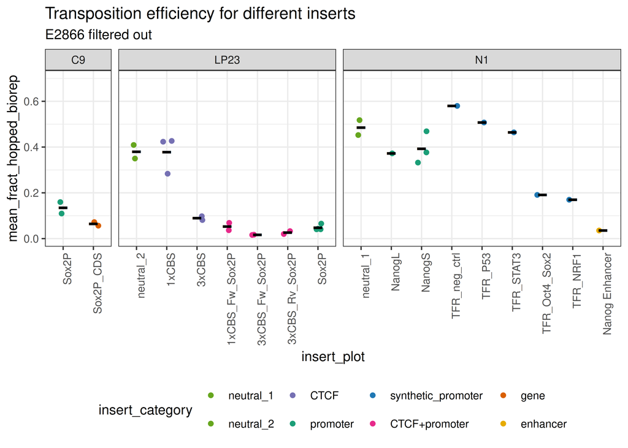

```r
summary_stats = plot_dat2 %>%
  group_by(insert_plot, launch_pad, insert_category) %>%
  summarise(mean_fract_hopped = mean(mean_fract_hopped_biorep)) %>% ungroup()

pHopEff_LP_inserts_V2 =
  plot_dat2 %>%
  ggplot(aes(x = insert_plot, y = mean_fract_hopped_biorep,
             col = insert_category)) +
  #geom_jitter(alpha = 0.8, size = 2, width = 0.2) +
  #geom_jitter(alpha = 0.8, size = 2, width = 0.2, height = 0) +
  geom_point(position = position_jitter(width = 0.2, height = 0, seed = 1)) +
  geom_point(data = summary_stats, aes(x = insert_plot, y = mean_fract_hopped),
             shape = "-",
             size = 10,
             color = "black") +
  facet_nested(~ launch_pad, scales = "free_x", space = "free_x") +
  scale_x_discrete(
    drop = TRUE,
    labels = function(x) sub(".*__", "", x)
  ) +
  scale_y_continuous(limits = c(0, 0.7)) +
  ggtitle("Transposition efficiency for different inserts",
          subtitle = "E2866 filtered out") +
  theme_bw() +
  theme(axis.text.x = element_text(angle = 90, hjust = 1),
        legend.position = "bottom") +
  scale_color_manual(values = insert_category_cols)

pHopEff_LP_inserts_V2
```

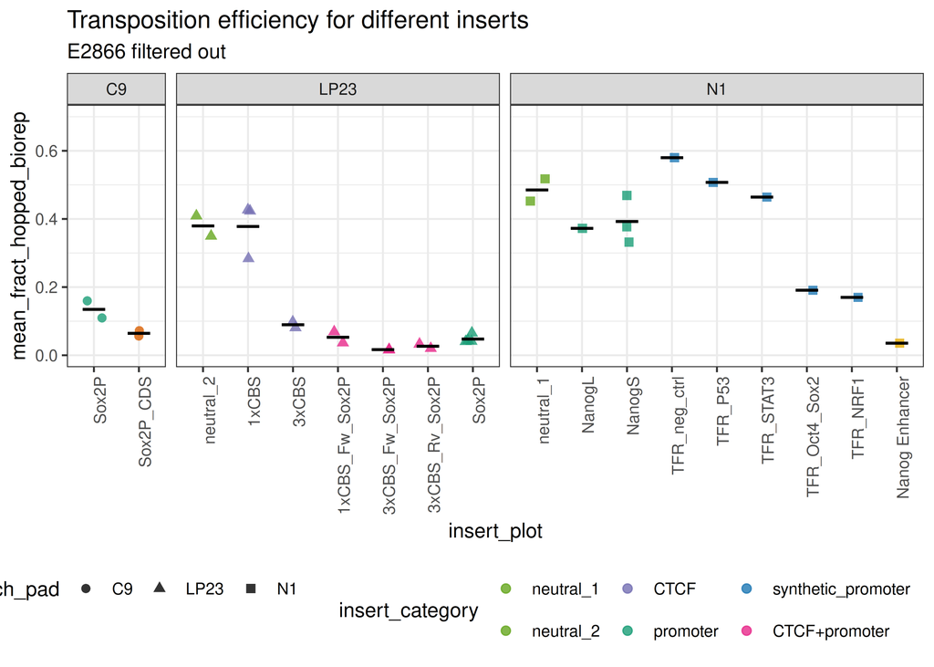

```r
# new, use geom_crossbar instead of point with the shape "-", this has some intrinsic bias of positioning
summary_stats = plot_dat2 %>%
  group_by(insert_plot, launch_pad, insert_category) %>%
  summarise(mean_fract_hopped = mean(mean_fract_hopped_biorep), .groups = "drop")

plot_dat2 %>%
  ggplot(aes(x = insert_plot, y = mean_fract_hopped_biorep,
             col = insert_category, shape = launch_pad)) +
  geom_jitter(alpha = 0.8, size = 2, width = 0.2, height = 0) +
  geom_crossbar(
    data = summary_stats,
    aes(x = insert_plot,
        y = mean_fract_hopped,
        ymin = mean_fract_hopped,
        ymax = mean_fract_hopped),
    width = 0.5,
    color = "black",
    linewidth = 0.3,
    inherit.aes = FALSE
  ) +
  facet_nested(~ launch_pad, scales = "free_x", space = "free_x") +
  scale_y_continuous(limits = c(0, 0.7)) +
  ggtitle("Transposition efficiency for different inserts",
          subtitle = "E2866 filtered out") +
  theme_bw() +
  theme(axis.text.x = element_text(angle = 90, hjust = 1),
        legend.position = "bottom") +
  scale_color_manual(values = insert_category_cols)
```

## Fig 3B - Insert size of chosen LPs

Same filtering as before: - here we take the mean of the biologcial replicates - and we take the mean of the size of the NanogS constructs, the only difference here is the polyA tail, the promoter is the same. Insert size ranges from 1485 to 1671 bp.

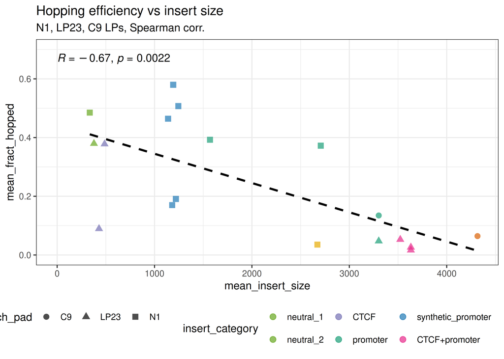

```r
plot_dat3 =
hopping_eff_tib_wide_annot2 %>%
  select(launch_pad, insert, insert_category, bio_rep, mean_fract_hopped, genotype, experiment, insert_size) %>%
  filter(launch_pad %in% c("LP23", "N1", "C9"),
         genotype == "WT",
         experiment != "E2866") %>%
  mutate(insert_plot = case_when(insert == "pME016" ~ "1xCBS",
                                 insert %in% c("pCM002", "pCM008", "pCM010") ~ "NanogS",
                                 insert == "pME034" ~ "Sox2P",
                                 insert == "pME041" ~ "Sox2P_CDS",
                                 insert == "CRE6" ~ "neutral_2",
                                 insert == "pLD037" ~ "neutral_1",
                                 insert == "pME013" ~ "1xCBS",
                                 insert == "pME038" ~ "3xCBS",
                                 insert == "pMK01" ~ "3xCBS_Fw_Sox2P",
                                 insert == "pMK02" ~ "3xCBS_Rv_Sox2P",
                                 insert == "pMK03" ~ "1xCBS_Fw_Sox2P",
                                 insert == "pCM003" ~ "NanogL",
                                 insert == "pMV001" ~ "Nanog Enhancer",
                                 .default = insert))  %>%
  mutate(insert_plot = factor(insert_plot,
                              levels = (c("neutral_1", "neutral_2", "1xCBS", "3xCBS", "1xCBS_Fw_Sox2P", "3xCBS_Fw_Sox2P", "3xCBS_Rv_Sox2P", "Sox2P", "Sox2P_CDS", "NanogL", "NanogS", "TFR_neg_ctrl", "TFR_P53", "TFR_STAT3", "TFR_Oct4_Sox2", "TFR_NRF1", "Nanog Enhancer")))) %>% #order them for plotting
 mutate(bio_rep = case_when(insert == "pCM002" ~ "rep1", #use the different NanogP cargos as different reps
                             insert == "pCM008" ~ "rep2",
                             insert == "pCM010" ~ "rep3",
                             .default = bio_rep)) %>%
  mutate(insert_category = factor(insert_category, levels = insert_cat_levels)) %>%
  group_by(launch_pad, insert_plot, bio_rep, insert_category, insert_size) %>%
  summarize(mean_fract_hopped_biorep = mean(mean_fract_hopped), .groups = "drop") %>% #calculate mean per bio_rep from tech_reps
  group_by(launch_pad, insert_plot, insert_category) %>% # combine per insert construct
  summarize(mean_fract_hopped = mean(mean_fract_hopped_biorep),
            mean_insert_size = mean(insert_size),
            .groups = "drop") %>%
  mutate(insert_lp = paste(launch_pad, insert_plot, sep = "_"))


ggplot(plot_dat3,
       aes(x = mean_insert_size, y = mean_fract_hopped, color = insert_category, shape = launch_pad)) +
  geom_point(size = 2.5, alpha = 0.7) +
  geom_smooth(
    aes(group = 1),
    method = "lm",
    se = FALSE,
    linetype = "dashed",
    color = "black") +
  stat_cor(
    data = plot_dat3,
    aes(x = mean_insert_size, y = mean_fract_hopped),
    method = "spearman",
    inherit.aes = FALSE) +
  scale_x_continuous(limits = c(0, NA)) +
  scale_y_continuous(limits = c(0, 0.7)) +
  ggtitle("Hopping efficiency vs insert size", subtitle = "N1, LP23, C9 LPs, Spearman corr.") +
  theme_bw() +
  scale_color_manual(values = insert_category_cols) +
  theme(legend.position = "bottom")
```

# Corrlate hopping efficiency with expression

Here we use TF-reporters that he measured by FACS.

## Load FACS data

```r
#Load FCS files
fcs_files_E2820_TF_rep = dir("/home/c.moene/projects/hopping_technology/04_Hopping_eff_insert_activity/FACS_files/E2820_TF_reporters", full.names = T)
names(fcs_files_E2820_TF_rep) = str_remove(str_remove(str_remove(fcs_files_E2820_TF_rep, '.*/'), "_Single Cells.fcs"), "export_cell_lines_")


annotation_file_E2820 = tibble(filenames = names(fcs_files_E2820_TF_rep),
                               full_filename = fcs_files_E2820_TF_rep,
                               insert = case_when(grepl("L05", filenames) ~ "STAT3",
                                                  grepl("L06", filenames) ~ "TP53",
                                                  grepl("L07", filenames) ~ "OCT4_SOX2",
                                                  grepl("L08", filenames) ~ "NFYA",
                                                  grepl("L09", filenames) ~ "random2",
                                                  grepl("L10", filenames) ~ "random1",
                                                  grepl("L11", filenames) ~ "NRF1",
                                                  grepl("Nanog", filenames) ~ "Nanog promoter",
                                                  .default = "WT"),
                               clone_tmp = split_string(filenames, "_", 3),
                               clone = case_when(clone_tmp == "NA" ~ "1",
                                                 .default = clone_tmp)) %>%
  select(-clone_tmp)


# Load FCS files
flowset_E2820 = flowCore::read.flowSet(files = annotation_file_E2820$full_filename, alter.names = T, truncate_max_range = F, ignore.text.offset = T)

#make dataframe
annotation_file_E2820 = data.frame(annotation_file_E2820)
rownames(annotation_file_E2820) = annotation_file_E2820$filenames

flowCore::sampleNames(flowset_E2820) = annotation_file_E2820$filenames
flowCore::pData(flowset_E2820) = annotation_file_E2820

flowset_fluo_E2820 = flowset_E2820[,c('BL.B..530_30.A', 'YG.D..610_20.A')]
colnames(flowset_fluo_E2820) = c("GFP", "mCherry")
```

```r
total_cell_count_tmp = flowCore::keyword(flowset_fluo_E2820, "$TOT")[,'$TOT']
total_cell_count = as.numeric(total_cell_count_tmp)
names(total_cell_count) = names(total_cell_count_tmp)


median_mCherry = sapply(1:length(flowset_fluo_E2820), function(i){
  median(flowCore::exprs(flowset_fluo_E2820[[i]])[,'mCherry'])
})
names(median_mCherry) = sampleNames(flowset_fluo_E2820)


median_GFP = sapply(1:length(flowset_fluo_E2820), function(i){
  median(flowCore::exprs(flowset_fluo_E2820[[i]])[,'GFP'])
})
names(median_GFP) = sampleNames(flowset_fluo_E2820)

flowCore::pData(flowset_fluo_E2820)$median_mCherry = median_mCherry
flowCore::pData(flowset_fluo_E2820)$median_GFP = median_GFP

flowCore::pData(flowset_fluo_E2820)$total_cell_count = total_cell_count

fcs_tib = tibble(flowCore::pData(flowset_fluo_E2820))
```

## Normalize expression

```r
#subtract autofluorescence, normalize to GFP
autofluo_tib_comb = fcs_tib  %>%
  filter(name == "WT") %>%
  summarize(mCherry_WT = mean(median_mCherry),
            GFP_WT = mean(median_GFP) )

mCherry_WT <- autofluo_tib_comb$mCherry_WT
GFP_WT     <- autofluo_tib_comb$GFP_WT

expression_tib_comb = fcs_tib %>%
  mutate(median_mCherry_cor = median_mCherry - mCherry_WT,
         median_GFP_cor     = median_GFP - GFP_WT,
         GFP_norm           = median_GFP_cor / median_mCherry_cor)


#normalize to random 2 control (the mean of both replicates)
standard_tib = expression_tib_comb %>%
  filter(insert == "random2") %>%
  summarize(mCherry_standard = mean(median_mCherry_cor),
            GFP_standard = mean(median_GFP_cor) )

mCherry_standard <- standard_tib$mCherry_standard
GFP_standard <- standard_tib$GFP_standard

expression_tib_comb = expression_tib_comb %>%
  mutate(rel_mCherry_cor = median_mCherry_cor / mCherry_standard,
         rel_GFP_cor = median_GFP_cor / GFP_standard)
```

## Add hopping efficiency to it

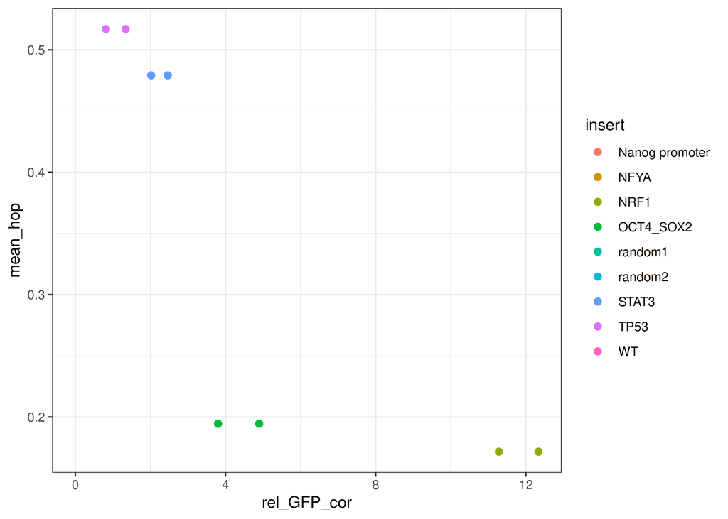

```r
# Filter for E2828 & E2866
tib_mean_hop_fract = hopping_eff_tib_wide_annot2 %>% filter(experiment %in% c("E2828", "E2866")) %>% group_by(insert) %>% summarize(mean_hop = mean(mean_fract_hopped)) %>% select(insert, mean_hop) %>%
  mutate(insert = case_when(insert == "TFR_NRF1" ~ "NRF1",
                            insert == "TFR_Nanog" ~ "Nanog promoter",
                            insert == "TFR_Oct4_Sox2" ~ "OCT4_SOX2",
                            insert == "TFR_P53" ~ "TP53",
                            insert == "TFR_Random2" ~ "random2",
                            insert == "TFR_STAT3" ~ "STAT3",
                            .default = insert
                            ))

tib_expr_TF = expression_tib_comb %>% select(insert, clone, median_mCherry_cor, rel_GFP_cor, median_GFP_cor, median_GFP)


tib_comb = tib_expr_TF %>% left_join(tib_mean_hop_fract, join_by(insert))

tib_comb %>%
  ggplot(aes(x = rel_GFP_cor, y = mean_hop, colour = insert)) +
  geom_point(size = 2) +
  theme_bw()
```

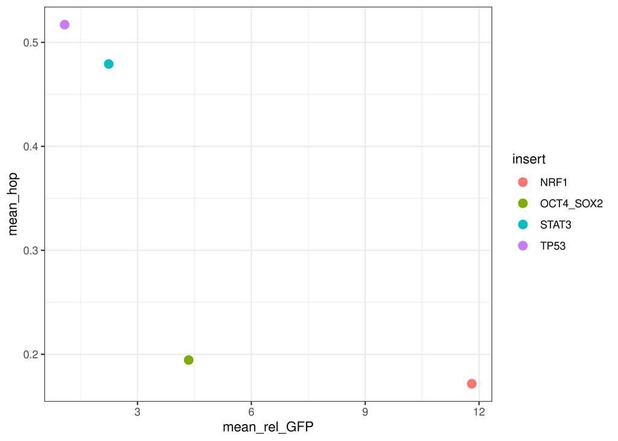

```r
tib_comb %>%
  group_by(insert) %>% summarize (mean_rel_GFP = mean(rel_GFP_cor),
                                  mean_hop = mean(mean_hop)) %>%
  drop_na() %>%
  ggplot(aes(x = mean_rel_GFP, y = mean_hop, colour = insert)) +
  geom_point(size = 3) +
  theme_bw()
```

```r
# saveRDS(tib_expr_TF, '/home/c.moene/projects/hopping_technology/04_Hopping_eff_insert_activity/files/CM20260415_fluorescence_TF_reporters.rds')
```

**Conclusion:** The nanog promoter has a different size than the rest and E2866 has the issue that the hopping efficiency is calculated after they have been sorted for GFP negative cells, possibly introducing some bias.

To-do: Only use the data E2828 and without Nanog.

random2 has higher GFP values than WT.

## Color scheme for TFR

```r
promoter_cols <- c(
  "NRF1" = "#36B885",
  "OCT4_SOX2" = "#34BFC6",
  "STAT3" = "#37449C",
  "TP53" = "#2179B4",
  "random2" = "#676767"
)
```

## Plot - hop effic vs activity

```r
# Select hopping efficiency of E2828
tib_hop_eff_E2828 =
hopping_eff_tib_wide_annot2 %>% filter(experiment %in% c("E2828")) %>%
  mutate(insert = case_when(insert == "TFR_NRF1" ~ "NRF1",
                            insert == "TFR_Oct4_Sox2" ~ "OCT4_SOX2",
                            insert == "TFR_P53" ~ "TP53",
                            insert == "TFR_neg_ctrl" ~ "random2",
                            insert == "TFR_STAT3" ~ "STAT3",
                            .default = insert))
```

## Fig 3E

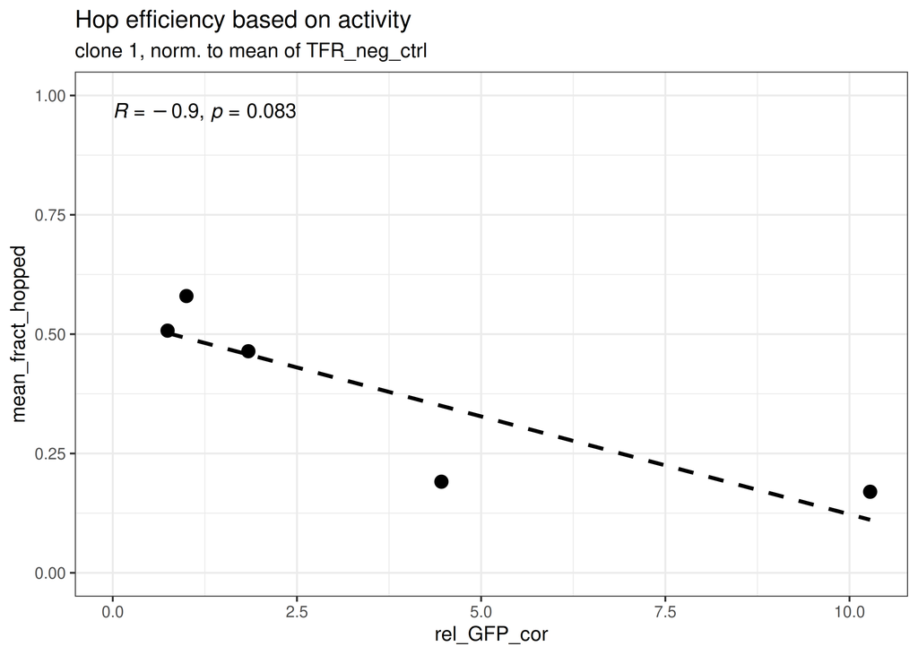

```r
#Plot only clone1, which has been used to hop
## Normalize to random2 of clone 1

standard_tib = expression_tib_comb %>%
  filter(insert == "random2" & clone == "1") %>%
  summarize(mCherry_standard_cl1 = mean(median_mCherry_cor),
            GFP_standard_cl1 = mean(median_GFP_cor) )

mCherry_standard_cl1 <- standard_tib$mCherry_standard_cl1
GFP_standard_cl1 <- standard_tib$GFP_standard_cl1

expression_tib_comb = expression_tib_comb %>%
  mutate(rel_mCherry_cor = median_mCherry_cor / mCherry_standard_cl1,
         rel_GFP_cor = median_GFP_cor / GFP_standard_cl1)

tib_expr_TF = expression_tib_comb %>% select(insert, clone, median_mCherry_cor, rel_GFP_cor, median_GFP_cor, median_GFP)

tib_comb_3 = tib_expr_TF %>%
  left_join(tib_hop_eff_E2828, join_by(insert)) %>% drop_na()

tib_comb_3 %>%
  filter(clone == "1") %>%
  ggplot(aes(x = rel_GFP_cor, y = mean_fract_hopped)) +
  geom_point(size = 3, col = "black") +
  geom_smooth(method = "lm",
              se = FALSE,
              linetype = "dashed",
              color = "black") +
  stat_cor(method = "spearman",
           inherit.aes = TRUE) +
  scale_x_continuous(limits = c(0, NA)) +
  scale_y_continuous(limits = c(0, 1)) +
  ggtitle("Hop efficiency based on activity", subtitle = "clone 1, norm. to mean of TFR_neg_ctrl") +
  theme_bw()
```

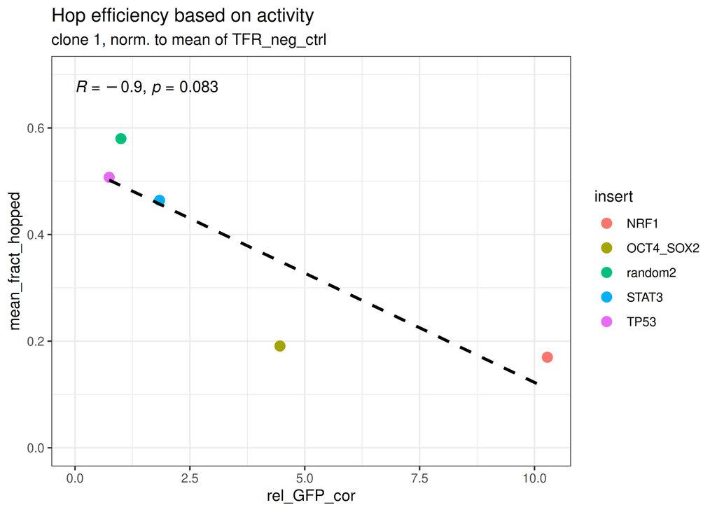

```r
#color by insert
tib_comb_3 %>%
  filter(clone == "1") %>%
  ggplot(aes(x = rel_GFP_cor, y = mean_fract_hopped, col = insert)) +
  geom_point(size = 3) +
  geom_smooth(method = "lm",
              se = FALSE,
              linetype = "dashed",
              color = "black") +
  stat_cor(aes(x = rel_GFP_cor, y = mean_fract_hopped),
           method = "spearman",
           inherit.aes = FALSE) +
  scale_x_continuous(limits = c(0, NA)) +
  scale_y_continuous(limits = c(0, 0.7)) +
  ggtitle("Hop efficiency based on activity", subtitle = "clone 1, norm. to mean of TFR_neg_ctrl") +
  theme_bw()
```

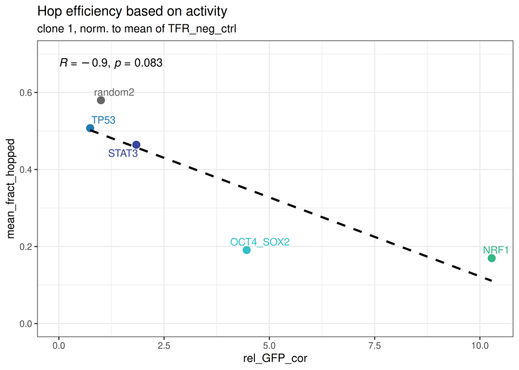

```r
# text label points
tib_comb_3 %>%
  filter(clone == "1") %>%
  ggplot(aes(x = rel_GFP_cor, y = mean_fract_hopped, col = insert)) +
  geom_point(size = 3) +
  geom_text_repel(aes(label = insert),
                  show.legend = FALSE,
                  size = 3.5) +
  geom_smooth(method = "lm",
              se = FALSE,
              linetype = "dashed",
              color = "black") +
  stat_cor(aes(x = rel_GFP_cor, y = mean_fract_hopped),
           method = "spearman",
           inherit.aes = FALSE) +
  scale_x_continuous(limits = c(0, NA)) +
  scale_y_continuous(limits = c(0, 0.7)) +
  ggtitle("Hop efficiency based on activity", subtitle = "clone 1, norm. to mean of TFR_neg_ctrl") +
  theme_bw() +
  theme(legend.position = "none") +
  scale_color_manual(values = promoter_cols)
```

## Fig 3D - Plot - density of fluorescence

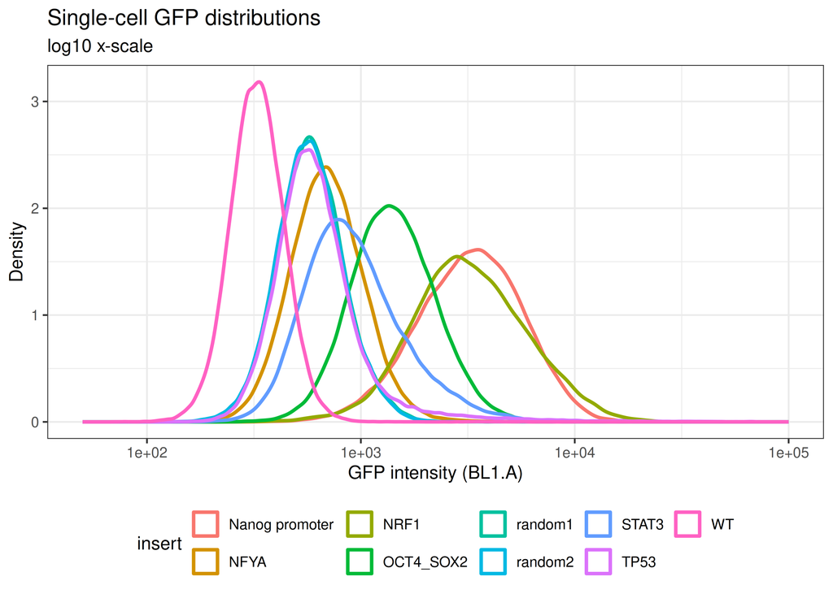

```r
# extract single-cell GFP values from each file
dens_tib_E2820 <- map_dfr(seq_along(flowset_fluo_E2820), function(i) {
  tibble(
    GFP = flowCore::exprs(flowset_fluo_E2820[[i]])[, "GFP"],
    filename = flowCore::sampleNames(flowset_fluo_E2820)[i]
  )
}) %>%
  left_join(
    fcs_tib %>% select(filenames, insert, clone),
    by = c("filename" = "filenames")
  )


# density plot
pDensity_E2820 =
ggplot(dens_tib_E2820, aes(x = GFP, colour = insert)) +
  geom_density(alpha = 0.3, linewidth = 1) +
  scale_x_continuous(trans = "log10", limits = c(50, 1e5)) +
  theme_bw() +
  labs(
    title = "Single-cell GFP distributions",
    subtitle = "log10 x-scale",
    x = "GFP intensity (BL1.A)",
    y = "Density") +
  theme(legend.position="bottom")

pDensity_E2820
```

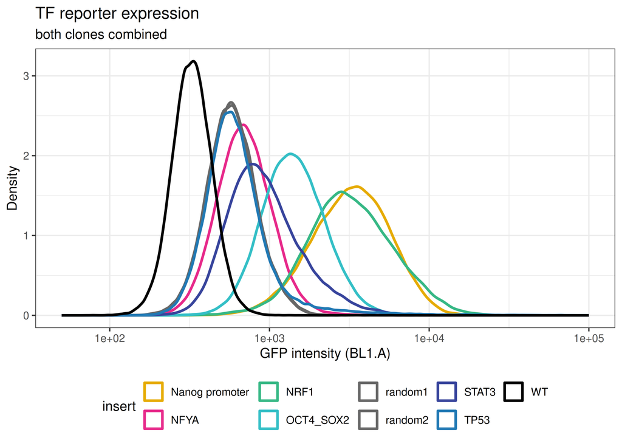

```r
#Assign colors to the inserts
insert_cols_E2820 <- c(
  "WT" = "black",
  "random1" = "#676767",
  "random2" = "#676767",
  "STAT3" = "#37449C",
  "TP53" = "#2179B4",
  "OCT4_SOX2" = "#34BFC6",
  "NFYA" = "#E7298A",
  "NRF1" = "#36B885",
  "Nanog promoter" = "#E6AB02"
)


# Plot replicate clones together
pDensity_E2820 =
ggplot(dens_tib_E2820, aes(x = GFP, colour = insert)) +
  geom_density(alpha = 0.3, linewidth = 1) +
  scale_colour_manual(values = insert_cols_E2820) +
  scale_x_continuous(trans = "log10", limits = c(50, 1e5)) +
  theme_bw() +
  labs(
    title = "TF reporter expression",
    subtitle = "both clones combined",
    x = "GFP intensity (BL1.A)",
    y = "Density"
  ) +
  theme(legend.position = "bottom")

pDensity_E2820
```

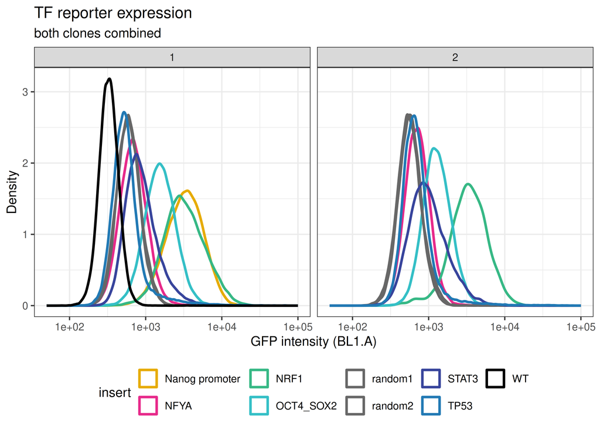

```r
# by replicate
pDensity_E2820_rep =
ggplot(dens_tib_E2820, aes(x = GFP, colour = insert)) +
  geom_density(alpha = 0.3, linewidth = 1) +
  scale_colour_manual(values = insert_cols_E2820) +
  scale_x_continuous(trans = "log10", limits = c(50, 1e5)) +
  facet_wrap(~ clone) +
  theme_bw() +
  labs(
    title = "TF reporter expression",
    subtitle = "both clones combined",
    x = "GFP intensity (BL1.A)",
    y = "Density"
  ) +
  theme(legend.position = "bottom")

pDensity_E2820_rep
```

[figure not shown]

```r
# Plot clone 1
pDensity_E2820_clone1 =
  dens_tib_E2820 %>% filter(clone == "1" & insert %in% c("WT", "random2", "TP53", "STAT3", "OCT4_SOX2", "NRF1")) %>%
  mutate(insert = factor(insert, levels = c("WT", "random2", "TP53", "STAT3", "OCT4_SOX2", "NRF1"))) %>%
  ggplot(aes(x = GFP, colour = insert)) +
  geom_density(alpha = 0.3, linewidth = 1) +
  scale_colour_manual(values = insert_cols_E2820) +
  scale_x_continuous(trans = "log10", limits = c(50, 1e5)) +
  theme_bw() +
  labs(
    title = "TF reporter expression",
    subtitle = "both clones combined",
    x = "GFP intensity (BL1.A)",
    y = "Density"
  ) +
  theme(legend.position = "right")

pDensity_E2820_clone1
```

**Conclusion:** There is a negative correlation between activity and hopping, the more active, the less good the transposon hops. I am inclined to take the mean of both clones because of TP53. If you take the mean of both clones its slightly higher than the random control, if you select clone one its lower than the random2 control.

# Fig S4B - Deletion delD and delE

Besides the TF reporters we have additional conditions that we can compare. Sox2P in LP-116kb in WT, DelD, DelE Sox2P in LP-116kb in WT, mCh_Deletion Sox2P in LP-161kb in WT, mCh_Deletion

Nanog long vs short promoter (same activity, different length)

## Load DelD and DelE FACS data

E2270 - Hopping of DelD and DelE from LP-116kb. Replicate 1 E2339 - Hopping of DelD and DelE from LP-116kb. Replicate 2

### Load E2270

```r
fcs_files_E2270 = dir('/DATA/projects/CTCF_Sox2/FACS_files/export_fcs_R_E2270_DelD_DelE',
                      full.names = T)

fcs_files_E2270_tib = tibble(file = fcs_files_E2270) %>%
  mutate(sample_name_tmp = split_string(str_remove(file, '.*/'), "_", 4, 10)) %>%
  mutate(cell_line = case_when(grepl("E12", sample_name_tmp) ~ "23_34_E12",
                               grepl("D2", sample_name_tmp) ~ "23_34_D2",
                               grepl("23_34A", sample_name_tmp) ~ "23_34A",
                               grepl("sort_neg_ctrl", sample_name_tmp) ~ "WT"),

         treatment = case_when(grepl("UT", sample_name_tmp) ~ "untreated",
                               grepl("PB", sample_name_tmp) ~ "PB",
                               grepl("SB", sample_name_tmp) ~ "SB",
                               grepl("sort_neg_ctrl", sample_name_tmp) ~ "untreated"),

         genotype = case_when(cell_line == "23_34A" ~ "WT",
                              cell_line == "23_34_D2" ~ "delD",
                              cell_line == "23_34_E12" ~ "delE",
                              .default = "WT"), #very little cells were measured in WT control, check if usable

         clone_name = case_when(grepl("D2", cell_line) ~ "clone_D2",
                                grepl("E12", cell_line) ~ "clone_E12",
                                grepl("23_34A", cell_line) ~ "23_34A",
                                .default = genotype),
         replicate = "rep1",
         fcs_filter = "mCh+",
         timepoint = "sort",
         experiment = "E2270",
         flowcytometer = "sorter",
         sample_name = paste0(experiment, "_", cell_line, "_", genotype, "_", treatment),
         date = "me20230523")
```

### Load E2339

```r
fcs_files_E2339= dir("/DATA/projects/CTCF_Sox2/FACS_files/export_fcs_R_E2339_DelD_DelE",
                      full.names = T)

fcs_files_E2339_tib = tibble(file = fcs_files_E2339) %>%
  mutate(sample_name_tmp = split_string(str_remove(file, '.*/'), "_", 2, 8)) %>%
  mutate(cell_line = case_when(grepl("23_34A_ctrl", sample_name_tmp) ~ "23_34A",
                               grepl("23_DelD", sample_name_tmp) ~ "23_34_D2",
                               grepl("23_DelE", sample_name_tmp) ~ "23_34_E12",
                               grepl("F121_ctrl", sample_name_tmp) ~ "F121",
                               grepl("WT", sample_name_tmp) ~ "WT"),

          treatment = case_when(grepl("UT", sample_name_tmp) ~ "untreated",
                               grepl("PB", sample_name_tmp) ~ "PB",
                               grepl("SB", sample_name_tmp) ~ "SB",
                               grepl("ctrl", sample_name_tmp) ~ "untreated",
                               grepl("WT", sample_name_tmp) ~ "untreated"),

         genotype = case_when(cell_line == "23_34A" ~ "WT",
                              cell_line == "23_34_D2" ~ "delD",
                              cell_line == "23_34_E12" ~ "delE",
                              .default = "WT"),

         clone_name = case_when(grepl("23_DelD", sample_name_tmp) ~ "clone_D2",
                                grepl("23_DelE", sample_name_tmp) ~ "clone_E12",
                                .default = cell_line),
         replicate = "rep2",
         fcs_filter = "mCh+",
         timepoint = "sort",
         experiment = "E2339",
         flowcytometer = "sorter",
         sample_name = paste0(experiment, "_", cell_line, "_", genotype, "_", treatment),
         date = "me20231024"
         )
```

## Combine data

```r
fcs_files_combined = bind_rows(fcs_files_E2270_tib,
                 fcs_files_E2339_tib) %>%
  mutate(cell_line = factor(cell_line, c("23_34A", "23_34_D2",  "23_34_E12", "F121", "WT"))) %>%
  mutate(treatment = factor(treatment, c('untreated','PB','SB')))


#not all channels are in all datasets, subset the ones we need (which are in all sets) so we can load all at once
flowset_all = read.flowSet(files = fcs_files_combined$file, alter.names = T, truncate_max_range = F, column.pattern = 'BL.B..530_30.A|YG.D..610_20.A|V.F..450_50.A|FSC.A|SSC.A')
```

```r
#add sample names and phenodata
sampleNames(flowset_all) = fcs_files_combined$sample_name
pData(flowset_all)$name = fcs_files_combined$sample_name
pData(flowset_all)$sample_name = fcs_files_combined$sample_name

pheno_data_tib = left_join(pData(flowset_all), fcs_files_combined, join_by(sample_name == sample_name) )
rownames(pheno_data_tib) = fcs_files_combined$sample_name

pData(flowset_all) = pheno_data_tib

#order the fluorophores and rename them
flowset_fluo = flowset_all[,c('BL.B..530_30.A', 'YG.D..610_20.A', 'V.F..450_50.A', 'FSC.A', 'SSC.A')]
colnames(flowset_fluo) = c("GFP", "mCherry", "mTurq", 'FSC', 'SSC')

N_cells = sapply(1:length(flowset_fluo), function(i){nrow(flowset_fluo[[i]])})
pData(flowset_fluo)$N_cells = N_cells
fcs_files_combined$N_cells = N_cells


rm(flowset_all)
```

## Statistics

```r
# Calculate median expression
tib_median = as_tibble(rownames = "name", fsApply(flowset_fluo, each_col, median)) %>%
  dplyr::rename(median_GFP = GFP,
         median_mCh = mCherry,
         median_mTurq = mTurq) %>%
  select(-c("FSC", "SSC"))

# Calculate mean expression
tib_mean = as_tibble(rownames = "name", fsApply(flowset_fluo, each_col, mean)) %>%
  dplyr::rename(mean_mCh = mCherry,
         mean_GFP = GFP,
         mean_mTurq = mTurq) %>%
  select(-c("FSC", "SSC"))

# Calculate standard deviation
tib_std = as_tibble(rownames = "name", fsApply(flowset_fluo, each_col, sd)) %>%
  dplyr::rename(std_mCh = mCherry,
         std_GFP = GFP,
         std_mTurq = mTurq) %>%
  select(-c("FSC", "SSC"))

tib_mean_median_std = tib_median %>%
  left_join(tib_mean, by = "name") %>%
  left_join(tib_std, by = "name") %>%
  mutate(CV_mCh = std_mCh/mean_mCh,
         CV_GFP = std_GFP/mean_GFP,
         CV_mTurq = std_mTurq/mean_mTurq)

tib_all = pheno_data_tib %>% left_join(tib_mean_median_std, by = "name")

#To add cell number
tib_all = tib_all %>% left_join(fcs_files_combined)
```

## Correct and normalize medians

```r
#subtract autofluorescence
autofluo_tib_comb = tib_all  %>%
  filter(cell_line == "WT") %>% #WT rep1 has low amount of cells recorded
  group_by(date) %>%
  summarize(mTurq_WT = mean(median_mTurq),
           mCherry_WT = mean(median_mCh),
            GFP_WT = mean(median_GFP) )

#normalize to GFP
expression_tib_comb = tib_all %>%
  left_join(autofluo_tib_comb, join_by(date)) %>%
  mutate(median_mTurq_cor = median_mTurq - mTurq_WT,
         median_mCherry_cor = median_mCh - mCherry_WT,
         median_GFP_cor = median_GFP - GFP_WT) %>%
  mutate(mTurq_norm = median_mTurq_cor / median_GFP_cor,
         mCherry_norm = median_mCherry_cor / median_GFP_cor)

#normalize to 23_34A (to compare between measurement days and to compare them in general)
standard_tib = expression_tib_comb %>%
  group_by(date, experiment) %>%
  filter(cell_line == "23_34A" & treatment == "untreated") %>%
  summarize(mTurq_norm_standard = mean(mTurq_norm),
            mCherry_norm_standard = mean(mCherry_norm),
            GFP_standard = mean(median_GFP_cor))

expression_tib_comb = expression_tib_comb %>%
  left_join(standard_tib, join_by(date, experiment)) %>%
  mutate(rel_mTurq = mTurq_norm / mTurq_norm_standard,
         rel_mCherry = mCherry_norm / mCherry_norm_standard,
         rel_GFP_cor = median_GFP_cor / GFP_standard)
```

## Correlate hopping efficiency with activity

E2270 (hopping) and E2282 (mapping) are the exp for rep1 E2239 (hopping) and E2347 (mapping) are the exp for rep2

```r
# hopping efficiency
tib_hop_eff_delD_delE = hopping_eff_tib_wide_annot2 %>%
  filter(experiment %in% c("E2282", "E2347") & insert == "pME034") %>%
  mutate(cell_line = case_when(genotype == "delD2" ~ "23_34_D2",
                               genotype == "delE12" ~ "23_34_E12",
                               genotype == "WT" ~ "23_34A",
                               .default = genotype)) %>%
  dplyr::rename(replicate = bio_rep) %>%
  select(mean_fract_hopped, mean_fract_home, cell_line, replicate, insert, insert_size, GC_content)

tib_try = expression_tib_comb %>% left_join(tib_hop_eff_delD_delE, join_by(cell_line, replicate))
```

### Fig S4B Final paper plot

We have hopping from two biological replicates and one FACS measurment per clone.

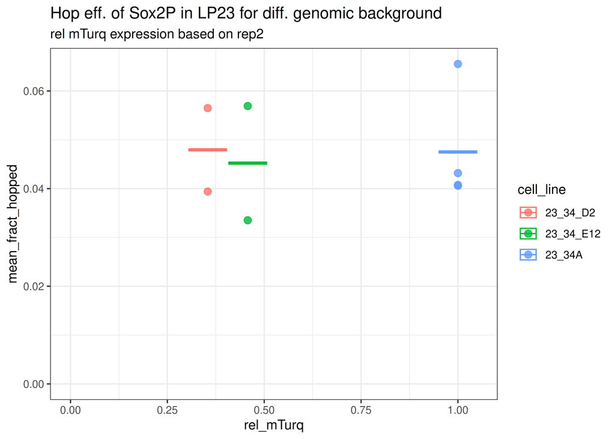

```r
# Hopping efficiency of each individual replicate
tib_hop_eff_delD_delE_allRep =
hopping_eff_tib_wide_annot2 %>%
  filter(insert == "pME034" & launch_pad == "LP23") %>%
  mutate(cell_line = case_when(genotype == "WT" ~ "23_34A",
                               genotype == "delD2" ~ "23_34_D2",
                               genotype == "delE12" ~ "23_34_E12"))

# rel_mTurq level of rep2
tib_rel_mTurq_rep2 =  expression_tib_comb %>%
  filter(treatment == "untreated" & replicate == "rep2") %>%
  select(cell_line, rel_mTurq, mTurq_norm)

# mean of hopping efficiency
tib_summary = tib_hop_eff_delD_delE_allRep %>%
  group_by(genotype) %>%
  summarise(mean_fract_hopped = mean(mean_fract_hopped)) %>%
  mutate(cell_line = case_when(genotype == "WT" ~ "23_34A",
                               genotype == "delD2" ~ "23_34_D2",
                               genotype == "delE12" ~ "23_34_E12"))

tib_summary_V2 = tib_summary %>% left_join(tib_rel_mTurq_rep2, join_by(cell_line))


#combine to one tibble for plotting
tib_comb_DelD_DelE = tib_hop_eff_delD_delE_allRep %>%
  left_join(tib_rel_mTurq_rep2, join_by(cell_line))

# Plot
pDelD_DelE_cor_rep2 =
tib_comb_DelD_DelE %>%
  ggplot(aes(x = rel_mTurq, y = mean_fract_hopped, col = cell_line)) +
  geom_point(alpha = 0.8, size = 2.5) +
  geom_crossbar(
    data = tib_summary_V2,
      aes(x = rel_mTurq, y = mean_fract_hopped, ymin = mean_fract_hopped, ymax = mean_fract_hopped, col = cell_line),
    inherit.aes = FALSE,
    width = 0.1,
    alpha = 0.5) +
  scale_x_continuous(limits = c(0, NA)) +
  scale_y_continuous(limits = c(0, NA)) +
  ggtitle("Hop eff. of Sox2P in LP23 for diff. genomic background", subtitle = "rel mTurq expression based on rep2") +
  theme_bw()

pDelD_DelE_cor_rep2
```

###Density plot

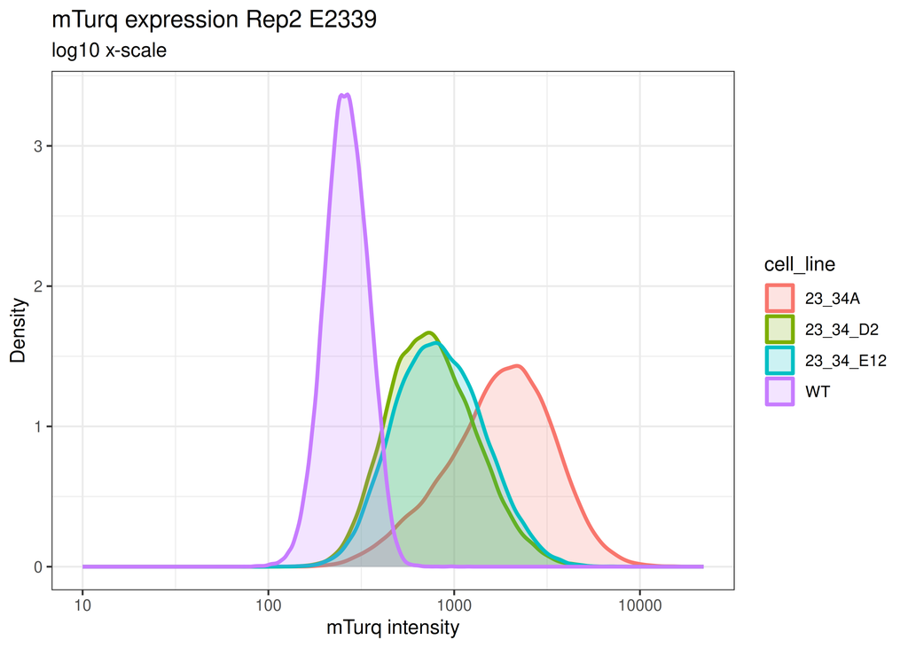

```r
# extract single-cell GFP values from each file
dens_tib_delD_delE <- map_dfr(seq_along(flowset_fluo), function(i) {
  tibble(
    GFP = flowCore::exprs(flowset_fluo[[i]])[, "GFP"],
    mTurq = flowCore::exprs(flowset_fluo[[i]])[, "mTurq"],
    mCherry = flowCore::exprs(flowset_fluo[[i]])[, "mCherry"],
    filename = flowCore::sampleNames(flowset_fluo)[i]
  )
}) %>%
  left_join(
    fcs_files_combined %>% select(sample_name, cell_line, genotype, treatment, experiment),
    by = c("filename" = "sample_name")
  )

# density plot for E2339 with WT control
pDensity_DelD_DelE_rep2 =
dens_tib_delD_delE %>% filter(treatment == "untreated" & experiment == "E2339" & cell_line %in% c("23_34A", "23_34_D2", "23_34_E12", "WT")) %>%
ggplot(aes(x = mTurq, colour = cell_line, fill = cell_line)) +
  geom_density(alpha = 0.2, linewidth = 1) +
  scale_x_continuous(trans = "log10", limits = c(10, NA)) +
  theme_bw() +
  theme(legend.position="right") +
  labs(
    title = "mTurq expression Rep2 E2339",
    subtitle = "log10 x-scale",
    x = "mTurq intensity",
    y = "Density")

pDensity_DelD_DelE_rep2
```

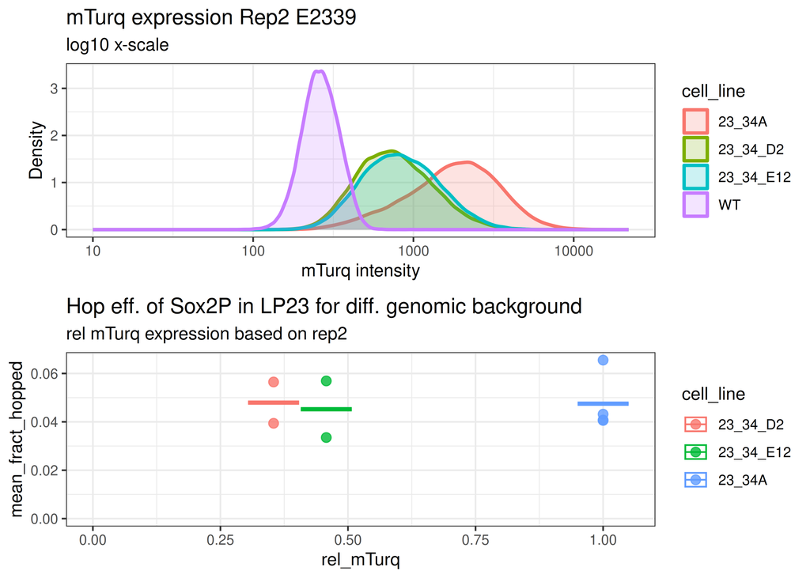

```r
plot_grid(pDensity_DelD_DelE_rep2, pDelD_DelE_cor_rep2, ncol = 1, align = "hv", axis = "lr")
```

# Fig S4C - C9 deletion

E2534/E2555: Rep1 and Rep2 of C9 Sox2P and Sox2P-CDS WT & mChDel hopping FACS rep1 = 01/05/2024 FACS rep2 = 02/05/2024

## Inspect hopping efficiency

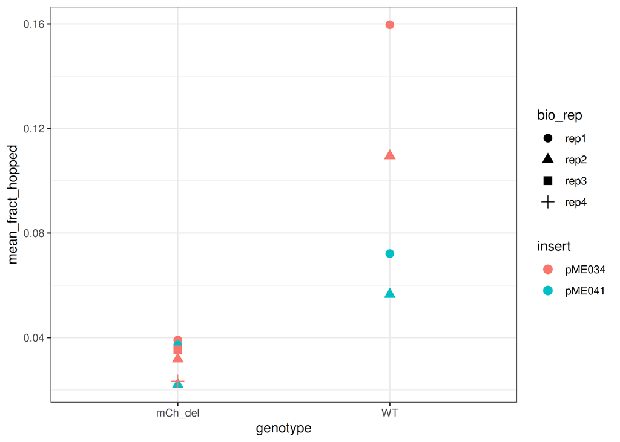

```r
hopping_eff_tib_wide_annot2 %>% filter(experiment %in% c("E2555", "E2716") & launch_pad == "C9") %>%
  ggplot(aes(x = genotype, y = mean_fract_hopped, col = insert, shape = bio_rep)) +
  geom_point(size = 3) +
  theme_bw()
```

Both constructs hop better in WT condition which reflects lower reporter activity.

## Load FACS data

### Load FACS files from rep1

```r
#Load FCS files
fcs_files_E2555_rep1 = dir("/home/c.moene/projects/hopping_technology/04_Hopping_eff_insert_activity/FACS_files/E2534_E2555/rep1/renamed_by_tube", full.names = T)
names(fcs_files_E2555_rep1) = str_remove(str_remove(fcs_files_E2555_rep1, '.*/'), ".fcs")


annotation_file_E2555_rep1 = tibble(filenames = names(fcs_files_E2555_rep1),
                               full_filename = fcs_files_E2555_rep1,
                               insert = case_when(grepl("_34", filenames) ~ "pME034",
                                                  grepl("_41", filenames) ~ "pME041",
                                                  .default = "control"),
                               launch_pad = case_when(grepl("C9", filenames) ~ "C9",
                                                  grepl("23", filenames) ~ "LP23",
                                                  .default = "none"),
                               genotype = case_when(grepl("mCh-", filenames) ~ "mCh_del",
                                                    .default = "WT"),
                               bio_rep = str_extract(filenames, "rep\\d+$"),
                               treatment = case_when(grepl("SB", filenames) ~ "SB",
                                                     grepl("PB", filenames) ~ "PB",
                                                     grepl("UT", filenames) ~ "untransfected",
                                                     .default = "control"))

# Load FCS files
flowset_E2555_rep1 = flowCore::read.flowSet(files = annotation_file_E2555_rep1$full_filename, alter.names = T, truncate_max_range = F, ignore.text.offset = T)

#make dataframe
annotation_file_E2555_rep1 = data.frame(annotation_file_E2555_rep1)
rownames(annotation_file_E2555_rep1) = annotation_file_E2555_rep1$filenames

flowCore::sampleNames(flowset_E2555_rep1) = annotation_file_E2555_rep1$filenames
flowCore::pData(flowset_E2555_rep1) = annotation_file_E2555_rep1

flowset_fluo_E2555_rep1 = flowset_E2555_rep1[,c('BL.B..530_30.A', 'YG.D..610_20.A', 'V.F..450_50.A')]
colnames(flowset_fluo_E2555_rep1) = c("GFP", "mCherry", "mTurq")
```

```r
total_cell_count_tmp = flowCore::keyword(flowset_fluo_E2555_rep1, "$TOT")[,'$TOT']
total_cell_count = as.numeric(total_cell_count_tmp)
names(total_cell_count) = names(total_cell_count_tmp)


median_mCherry = sapply(1:length(flowset_fluo_E2555_rep1), function(i){
  median(flowCore::exprs(flowset_fluo_E2555_rep1[[i]])[,'mCherry'])
})
names(median_mCherry) = sampleNames(flowset_fluo_E2555_rep1)


median_GFP = sapply(1:length(flowset_fluo_E2555_rep1), function(i){
  median(flowCore::exprs(flowset_fluo_E2555_rep1[[i]])[,'GFP'])
})
names(median_GFP) = sampleNames(flowset_fluo_E2555_rep1)


median_mTurq = sapply(1:length(flowset_fluo_E2555_rep1), function(i){
  median(flowCore::exprs(flowset_fluo_E2555_rep1[[i]])[,'mTurq'])
})
names(median_mTurq) = sampleNames(flowset_fluo_E2555_rep1)


flowCore::pData(flowset_fluo_E2555_rep1)$median_mCherry = median_mCherry
flowCore::pData(flowset_fluo_E2555_rep1)$median_GFP = median_GFP
flowCore::pData(flowset_fluo_E2555_rep1)$median_mTurq = median_mTurq

flowCore::pData(flowset_fluo_E2555_rep1)$total_cell_count = total_cell_count

fcs_tib_E2555_rep1 = tibble(flowCore::pData(flowset_fluo_E2555_rep1))
```

### Load FACS files from rep2

```r
#Load FCS files
fcs_files_E2555_rep2 = dir("/home/c.moene/projects/hopping_technology/04_Hopping_eff_insert_activity/FACS_files/E2534_E2555/rep2", full.names = T)
names(fcs_files_E2555_rep2) = str_remove(str_remove(str_remove(fcs_files_E2555_rep2, '.*/'), "_Single Cells.fcs"), "export_ME20240502_E2534_")


annotation_file_E2555_rep2 = tibble(filenames = names(fcs_files_E2555_rep2),
                               full_filename = fcs_files_E2555_rep2,
                               insert = case_when(grepl("_34", filenames) ~ "pME034",
                                                  grepl("_41", filenames) ~ "pME041",
                                                  .default = "control"),
                               launch_pad = case_when(grepl("C9", filenames) ~ "C9",
                                                  grepl("23", filenames) ~ "LP23",
                                                  .default = "none"),
                               genotype = case_when(grepl("mCh-", filenames) ~ "mCh_del",
                                                    .default = "WT"),
                               bio_rep = str_extract(filenames, "^rep\\d+"),
                               treatment = case_when(grepl("SB", filenames) ~ "SB",
                                                     grepl("PB", filenames) ~ "PB",
                                                     grepl("UT", filenames) ~ "untransfected",
                                                     .default = "control"))

# Load FCS files
flowset_E2555_rep2 = flowCore::read.flowSet(files = annotation_file_E2555_rep2$full_filename, alter.names = T, truncate_max_range = F, ignore.text.offset = T)

#make dataframe
annotation_file_E2555_rep2 = data.frame(annotation_file_E2555_rep2)
rownames(annotation_file_E2555_rep2) = annotation_file_E2555_rep2$filenames

flowCore::sampleNames(flowset_E2555_rep2) = annotation_file_E2555_rep2$filenames
flowCore::pData(flowset_E2555_rep2) = annotation_file_E2555_rep2

flowset_fluo_E2555_rep2 = flowset_E2555_rep2[,c('BL.B..530_30.A', 'YG.D..610_20.A', 'V.F..450_50.A')]
colnames(flowset_fluo_E2555_rep2) = c("GFP", "mCherry", "mTurq")
```

```r
total_cell_count_tmp = flowCore::keyword(flowset_fluo_E2555_rep2, "$TOT")[,'$TOT']
total_cell_count = as.numeric(total_cell_count_tmp)
names(total_cell_count) = names(total_cell_count_tmp)


median_mCherry = sapply(1:length(flowset_fluo_E2555_rep2), function(i){
  median(flowCore::exprs(flowset_fluo_E2555_rep2[[i]])[,'mCherry'])
})
names(median_mCherry) = sampleNames(flowset_fluo_E2555_rep2)


median_GFP = sapply(1:length(flowset_fluo_E2555_rep2), function(i){
  median(flowCore::exprs(flowset_fluo_E2555_rep2[[i]])[,'GFP'])
})
names(median_GFP) = sampleNames(flowset_fluo_E2555_rep2)


median_mTurq = sapply(1:length(flowset_fluo_E2555_rep2), function(i){
  median(flowCore::exprs(flowset_fluo_E2555_rep2[[i]])[,'mTurq'])
})
names(median_mTurq) = sampleNames(flowset_fluo_E2555_rep2)


flowCore::pData(flowset_fluo_E2555_rep2)$median_mCherry = median_mCherry
flowCore::pData(flowset_fluo_E2555_rep2)$median_GFP = median_GFP
flowCore::pData(flowset_fluo_E2555_rep2)$median_mTurq = median_mTurq

flowCore::pData(flowset_fluo_E2555_rep2)$total_cell_count = total_cell_count

fcs_tib_E2555_rep2 = tibble(flowCore::pData(flowset_fluo_E2555_rep2))
```

### Load FACS data from rep3 pME034 mCh-del

```r
#Load FCS files
fcs_files_E2716_rep3 = dir("/home/c.moene/projects/hopping_technology/04_Hopping_eff_insert_activity/FACS_files/E2687_E2716/rep3", full.names = T)
names(fcs_files_E2716_rep3) = str_remove(str_remove(str_remove(fcs_files_E2716_rep3, '.*/'), "_Single Cells.fcs"), "export_me20241030_E2687_")


annotation_file_E2716_rep3 = tibble(filenames = names(fcs_files_E2716_rep3),
                               full_filename = fcs_files_E2716_rep3,
                               insert = case_when(grepl("_34", filenames) ~ "pME034",
                                                  .default = "control"),
                               launch_pad = case_when(grepl("C9", filenames) ~ "C9",
                                                  grepl("23", filenames) ~ "LP23",
                                                  .default = "none"),
                               genotype = case_when(grepl("mCh-", filenames) ~ "mCh_del",
                                                    .default = "WT"),
                               bio_rep = "rep3",
                               treatment = case_when(grepl("UT", filenames) ~ "untransfected",
                                                     .default = "control"))

# Load FCS files
flowset_E2716_rep3 = flowCore::read.flowSet(files = annotation_file_E2716_rep3$full_filename, alter.names = T, truncate_max_range = F, ignore.text.offset = T)

#make dataframe
annotation_file_E2716_rep3 = data.frame(annotation_file_E2716_rep3)
rownames(annotation_file_E2716_rep3) = annotation_file_E2716_rep3$filenames

flowCore::sampleNames(flowset_E2716_rep3) = annotation_file_E2716_rep3$filenames
flowCore::pData(flowset_E2716_rep3) = annotation_file_E2716_rep3

flowset_fluo_E2716_rep3 = flowset_E2716_rep3[,c('BL.B..530_30.A', 'YG.D..610_20.A', 'V.F..450_50.A')]
colnames(flowset_fluo_E2716_rep3) = c("GFP", "mCherry", "mTurq")
```

```r
total_cell_count_tmp = flowCore::keyword(flowset_fluo_E2716_rep3, "$TOT")[,'$TOT']
total_cell_count = as.numeric(total_cell_count_tmp)
names(total_cell_count) = names(total_cell_count_tmp)


median_mCherry = sapply(1:length(flowset_fluo_E2716_rep3), function(i){
  median(flowCore::exprs(flowset_fluo_E2716_rep3[[i]])[,'mCherry'])
})
names(median_mCherry) = sampleNames(flowset_fluo_E2716_rep3)


median_GFP = sapply(1:length(flowset_fluo_E2716_rep3), function(i){
  median(flowCore::exprs(flowset_fluo_E2716_rep3[[i]])[,'GFP'])
})
names(median_GFP) = sampleNames(flowset_fluo_E2716_rep3)


median_mTurq = sapply(1:length(flowset_fluo_E2716_rep3), function(i){
  median(flowCore::exprs(flowset_fluo_E2716_rep3[[i]])[,'mTurq'])
})
names(median_mTurq) = sampleNames(flowset_fluo_E2716_rep3)


flowCore::pData(flowset_fluo_E2716_rep3)$median_mCherry = median_mCherry
flowCore::pData(flowset_fluo_E2716_rep3)$median_GFP = median_GFP
flowCore::pData(flowset_fluo_E2716_rep3)$median_mTurq = median_mTurq

flowCore::pData(flowset_fluo_E2716_rep3)$total_cell_count = total_cell_count

fcs_tib_E2716_rep3 = tibble(flowCore::pData(flowset_fluo_E2716_rep3))
```

### Load FACS data from rep4 pME034 mCh-del

```r
#Load FCS files
fcs_files_E2716_rep4 = dir("/home/c.moene/projects/hopping_technology/04_Hopping_eff_insert_activity/FACS_files/E2687_E2716/rep4", full.names = T)
names(fcs_files_E2716_rep4) = str_remove(str_remove(str_remove(fcs_files_E2716_rep4, '.*/'), "_Single Cells.fcs"), "export_me20241031_E2687_")


annotation_file_E2716_rep4 = tibble(filenames = names(fcs_files_E2716_rep4),
                               full_filename = fcs_files_E2716_rep4,
                               insert = case_when(grepl("_34", filenames) ~ "pME034",
                                                  .default = "control"),
                               launch_pad = case_when(grepl("C9", filenames) ~ "C9",
                                                  grepl("23", filenames) ~ "LP23",
                                                  .default = "none"),
                               genotype = case_when(grepl("mCh-", filenames) ~ "mCh_del",
                                                    .default = "WT"),
                               bio_rep = "rep4",
                               treatment = case_when(grepl("UT", filenames) ~ "untransfected",
                                                     .default = "control"))

# Load FCS files
flowset_E2716_rep4 = flowCore::read.flowSet(files = annotation_file_E2716_rep4$full_filename, alter.names = T, truncate_max_range = F, ignore.text.offset = T)

#make dataframe
annotation_file_E2716_rep4 = data.frame(annotation_file_E2716_rep4)
rownames(annotation_file_E2716_rep4) = annotation_file_E2716_rep4$filenames

flowCore::sampleNames(flowset_E2716_rep4) = annotation_file_E2716_rep4$filenames
flowCore::pData(flowset_E2716_rep4) = annotation_file_E2716_rep4

flowset_fluo_E2716_rep4 = flowset_E2716_rep4[,c('BL.B..530_30.A', 'YG.D..610_20.A', 'V.F..450_50.A')]
colnames(flowset_fluo_E2716_rep4) = c("GFP", "mCherry", "mTurq")
```

```r
total_cell_count_tmp = flowCore::keyword(flowset_fluo_E2716_rep4, "$TOT")[,'$TOT']
total_cell_count = as.numeric(total_cell_count_tmp)
names(total_cell_count) = names(total_cell_count_tmp)


median_mCherry = sapply(1:length(flowset_fluo_E2716_rep4), function(i){
  median(flowCore::exprs(flowset_fluo_E2716_rep4[[i]])[,'mCherry'])
})
names(median_mCherry) = sampleNames(flowset_fluo_E2716_rep4)


median_GFP = sapply(1:length(flowset_fluo_E2716_rep4), function(i){
  median(flowCore::exprs(flowset_fluo_E2716_rep4[[i]])[,'GFP'])
})
names(median_GFP) = sampleNames(flowset_fluo_E2716_rep4)


median_mTurq = sapply(1:length(flowset_fluo_E2716_rep4), function(i){
  median(flowCore::exprs(flowset_fluo_E2716_rep4[[i]])[,'mTurq'])
})
names(median_mTurq) = sampleNames(flowset_fluo_E2716_rep4)


flowCore::pData(flowset_fluo_E2716_rep4)$median_mCherry = median_mCherry
flowCore::pData(flowset_fluo_E2716_rep4)$median_GFP = median_GFP
flowCore::pData(flowset_fluo_E2716_rep4)$median_mTurq = median_mTurq

flowCore::pData(flowset_fluo_E2716_rep4)$total_cell_count = total_cell_count

fcs_tib_E2716_rep4 = tibble(flowCore::pData(flowset_fluo_E2716_rep4))
```

### Combine all four datasets

```r
fcs_tib_all = bind_rows(fcs_tib_E2555_rep1, fcs_tib_E2555_rep2, fcs_tib_E2716_rep3, fcs_tib_E2716_rep4)
fcs_tib_E2555 = bind_rows(fcs_tib_E2555_rep1, fcs_tib_E2555_rep2)
```

### Normalize expression

```r
#subtract autofluorescence
autofluo_tib_comb = fcs_tib_all  %>%
  filter(filenames %in% c("WT_neg_ctrl_rep1", "rep2_WT_neg_ctrl_rep2_001", "round1_WT_ctrl_005", "round2_WT_ctrl_005")) %>%
  group_by(bio_rep) %>%
  summarize(mTurq_WT = mean(median_mTurq),
            mCherry_WT = mean(median_mCherry),
            GFP_WT = mean(median_GFP))

#normalize to GFP
expression_tib_comb = fcs_tib_all %>%
  left_join(autofluo_tib_comb, join_by(bio_rep)) %>%
  mutate(median_mTurq_cor = median_mTurq - mTurq_WT,
         median_mCherry_cor = median_mCherry - mCherry_WT,
         median_GFP_cor = median_GFP - GFP_WT) %>%
  mutate(mTurq_norm = median_mTurq_cor / median_GFP_cor,
         mCherry_norm = median_mCherry_cor / median_GFP_cor)

#normalize to 23_34A (to compare between measurement days and to compare them in general)
standard_tib = expression_tib_comb %>%
  filter(launch_pad == "LP23" & genotype == "WT") %>%
  group_by(bio_rep) %>%
  summarize(mTurq_norm_standard = mean(mTurq_norm),
            mCherry_norm_standard = mean(mCherry_norm),
            GFP_standard = mean(median_GFP_cor))

expression_tib_comb = expression_tib_comb %>%
  left_join(standard_tib, join_by(bio_rep)) %>%
  mutate(rel_mTurq = mTurq_norm / mTurq_norm_standard,
         rel_mCherry = mCherry_norm / mCherry_norm_standard,
         rel_GFP_cor = median_GFP_cor / GFP_standard)
```

## Combine Hop efficiency with reporter expression

```r
hopping_eff_all =
hopping_eff_tib_wide_annot2 %>% filter(experiment %in% c("E2555", "E2716") & launch_pad == "C9") %>%
  mutate(join_name = paste0(insert, "_", bio_rep, "_", genotype))

expression_tib_comb_all =
expression_tib_comb %>% filter(treatment == "untransfected" & launch_pad == "C9") %>%
  mutate(join_name = paste0(insert, "_", bio_rep, "_", genotype)) %>%
  left_join(hopping_eff_all)
```

## Fig S4C bottom - Plot - mark mean of both replicates

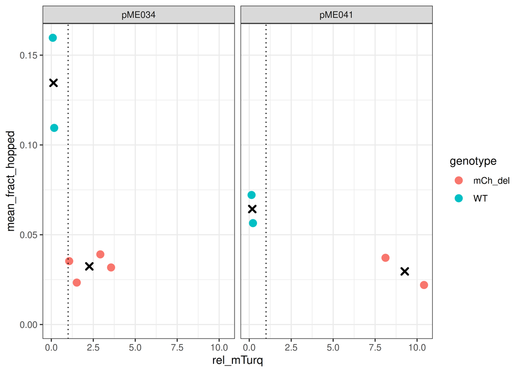

```r
mean_tib <- expression_tib_comb_all %>%
  group_by(insert, genotype) %>%
  summarise(
    rel_mTurq = mean(rel_mTurq, na.rm = TRUE),
    mean_fract_hopped = mean(mean_fract_hopped, na.rm = TRUE),
    .groups = "drop"
  )


#Without shaped replicates
expression_tib_comb_all %>%
  ggplot(aes(x = rel_mTurq, y = mean_fract_hopped, col = genotype)) +
  geom_point(size = 3) +
  geom_vline(xintercept = 1, col = "black", linetype = "dotted") +
  geom_point(
    data = mean_tib,
    aes(x = rel_mTurq, y = mean_fract_hopped),
    inherit.aes = FALSE,
    col = "black",
    size = 2,
    shape = 4,
    stroke = 1.4
  ) +
  facet_wrap(~ insert) +
  scale_x_continuous(limits = c(0, NA)) +
  scale_y_continuous(limits = c(0, NA)) +
  theme_bw()
```

#### Density plot

```r
# Export and plot rep1, untreated
## extract single-cell values from each file
dens_tib_E2555_rep1 <- map_dfr(seq_along(flowset_fluo_E2555_rep1), function(i) {
  tibble(
    GFP = flowCore::exprs(flowset_fluo_E2555_rep1[[i]])[, "GFP"],
    mTurq = flowCore::exprs(flowset_fluo_E2555_rep1[[i]])[, "mTurq"],
    mCherry = flowCore::exprs(flowset_fluo_E2555_rep1[[i]])[, "mCherry"],
    filename = flowCore::sampleNames(flowset_fluo_E2555_rep1)[i]
  )
}) %>%
  left_join(
    fcs_tib_E2555 %>% select(filenames, insert, genotype, bio_rep, treatment, name, launch_pad),
    by = c("filename" = "filenames")
  )

#rep2
dens_tib_E2555_rep2 <- map_dfr(seq_along(flowset_fluo_E2555_rep2), function(i) {
  tibble(
    GFP = flowCore::exprs(flowset_fluo_E2555_rep2[[i]])[, "GFP"],
    mTurq = flowCore::exprs(flowset_fluo_E2555_rep2[[i]])[, "mTurq"],
    mCherry = flowCore::exprs(flowset_fluo_E2555_rep2[[i]])[, "mCherry"],
    filename = flowCore::sampleNames(flowset_fluo_E2555_rep2)[i]
  )
}) %>%
  left_join(
    fcs_tib_E2555 %>% select(filenames, insert, genotype, bio_rep, treatment, name, launch_pad),
    by = c("filename" = "filenames")
  )

dens_tib_E2555_comb = bind_rows(dens_tib_E2555_rep1, dens_tib_E2555_rep2) %>%
  mutate(plot_category = case_when(bio_rep == "rep1" & name %in% c("WT_neg_ctrl_rep1", "23_34A_ctrl_rep1", "C9_34_mCh__UT_rep1", "C9_34_mCh-_UT_rep1", "C9_41_mCh__UT_rep1", "C9_41_mCh-_UT_rep1") ~ "set1",
                                   bio_rep == "rep2" & name %in% c("rep2_WT_neg_ctrl_rep2_001", "rep2_23_34A_ctrl_rep2_003", "rep2_C9_34_mCh+_UT_rep2_004", "rep2_C9_34_mCh-_UT_rep2_007", "rep2_C9_41_mCh-_UT_rep2_013", "rep2_C9_41_mCh+_UT_rep2_010") ~ "set2",
                                   .default = "other"))
```

### Fig S4C - Custom plot for paper

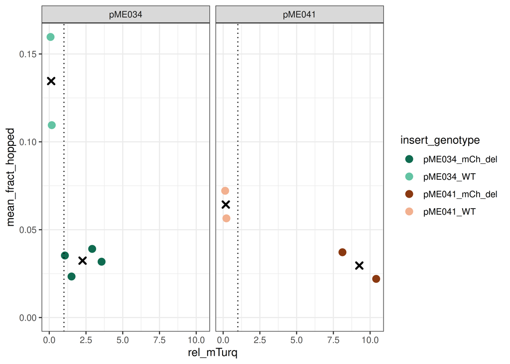

```r
# Add color palette for plotting
insert_genotype_cols <- c(
  "pME034_mCh_del" = "#0F6B50",
  "pME034_WT" = "#63C3A3",
  "pME041_mCh_del" = "#8A3911",
  "pME041_WT" = "#F2B08F"
)


#Add plotting variable
pDensity_C9_FACS_rep1_V3 =
dens_tib_E2555_comb %>%
  mutate(insert_genotype = paste0(insert, "_", genotype)) %>%
  filter(plot_category != "other" & bio_rep == "rep1" & insert != "control") %>%
  ggplot(aes(x = mTurq, colour = insert_genotype, fill = insert_genotype, linetype = launch_pad)) +
  geom_density(alpha = 0.2, linewidth = 1) +
  facet_grid(. ~ insert) +
  scale_x_continuous(trans = "log10", limits = c(10, NA)) +
  theme_bw() +
  theme(legend.position="right") +
  labs(
    title = "Single-cell mTurq distributions, rep1",
    subtitle = "log10 x-scale",
    x = "mTurq intensity",
    y = "Density") +
  scale_colour_manual(values = insert_genotype_cols) +
  scale_fill_manual(values = insert_genotype_cols)


#Add color variables to hopping efficinecy
pCor_C9_FACS_HopEff_V2 =
expression_tib_comb_all %>%
  mutate(insert_genotype = paste0(insert, "_", genotype)) %>%
  ggplot(aes(x = rel_mTurq, y = mean_fract_hopped, col = insert_genotype)) +
  geom_point(size = 3) +
  geom_vline(xintercept = 1, col = "black", linetype = "dotted") +
  geom_point(
    data = mean_tib,
    aes(x = rel_mTurq, y = mean_fract_hopped),
    inherit.aes = FALSE,
    col = "black",
    size = 2,
    shape = 4,
    stroke = 1.4
  ) +
  facet_wrap(~ insert) +
  scale_x_continuous(limits = c(0, NA)) +
  scale_y_continuous(limits = c(0, NA)) +
  theme_bw() +
  scale_colour_manual(values = insert_genotype_cols)

pCor_C9_FACS_HopEff_V2
```

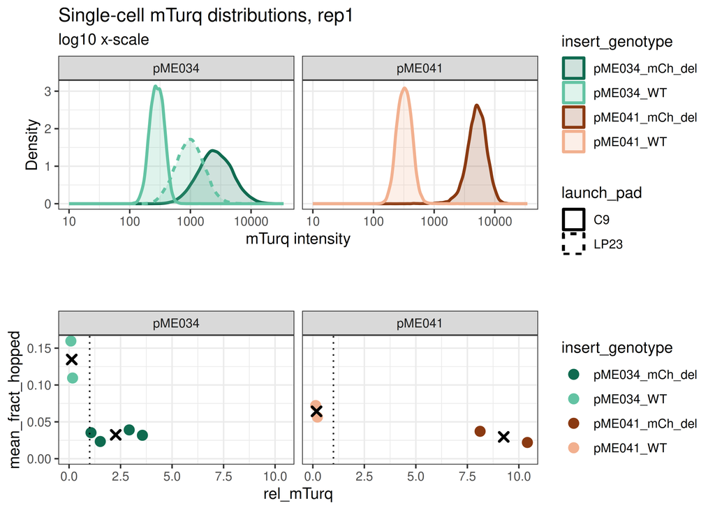

```r
plot_grid(pDensity_C9_FACS_rep1_V3, pCor_C9_FACS_HopEff_V2, ncol = 1, align = "hv", axis = "lr")
```

# Figure S4A - Nanog long vs short E1845

In E1891 we tested Nanog long (pCM003) vs Nanog small (pCM002) promoter almost same activity but different size.

```r
hopping_eff_tib_wide_annot2 %>% filter(experiment == "E1845" & insert %in% c("pCM002", "pCM003")) %>%
  mutate(merge_name = paste0(experiment, "_", launch_pad, "_", insert))
```

```
## # A tibble: 4 × 17
## # Groups:   launch_pad [1]
##   launch_pad sample_group      mean_fw mean_rv mean_fract_home mean_fract_hopped
##   <fct>      <chr>               <dbl>   <dbl>           <dbl>             <dbl>
## 1 N1         E1845_NanogL        0.547   0.666           0.606             0.394
## 2 N1         E1845_NanogL_tec…   0.546   0.752           0.649             0.351
## 3 N1         E1845_NanogS        0.481   0.592           0.536             0.464
## 4 N1         E1845_NanogS_tec…   0.429   0.622           0.526             0.474
## # ℹ 11 more variables: experiment <chr>, insert <chr>, insert_size <int>,
## #   CpG_count <int>, GC_content <dbl>, insert_seq <chr>, CpG_fract <dbl>,
## #   bio_rep <chr>, genotype <chr>, insert_category <chr>, merge_name <chr>
```

## Load FACS data

```r
#Load FCS files
fcs_files_E1891 = dir("/home/c.moene/projects/hopping_technology/04_Hopping_eff_insert_activity/FACS_files/E1845_E1891", full.names = T)
names(fcs_files_E1891) = str_remove(str_remove(str_remove(fcs_files_E1891, '.*/'), "_Single Cells.fcs"), "export_")


annotation_file_E1891 = tibble(filenames = names(fcs_files_E1891),
                               full_filename = fcs_files_E1891,
                               insert_name = case_when(grepl("S4", filenames) ~ "NanogS",
                                                  grepl("L1", filenames) ~ "NanogL",
                                                  .default = "control"),
                               insert = case_when(grepl("S4", filenames) ~ "pCM002",
                                                  grepl("L1", filenames) ~ "pCM003",
                                                  .default = "control"),
                               launch_pad = "N1",
                               genotype = "WT",
                               bio_rep = "rep1",
                               experiment = "E1845",
                               merge_name = paste0(experiment, "_", launch_pad, "_", insert))

# Load FCS files
flowset_E1891 = flowCore::read.flowSet(files = annotation_file_E1891$full_filename, alter.names = T, truncate_max_range = F, ignore.text.offset = T)

#make dataframe
annotation_file_E1891 = data.frame(annotation_file_E1891)
rownames(annotation_file_E1891) = annotation_file_E1891$filenames

flowCore::sampleNames(flowset_E1891) = annotation_file_E1891$filenames
flowCore::pData(flowset_E1891) = annotation_file_E1891

flowset_fluo_E1891 = flowset_E1891[,c('BL1.A')]
colnames(flowset_fluo_E1891) = c("GFP")
```

```r
total_cell_count_tmp = flowCore::keyword(flowset_fluo_E1891, "$TOT")[,'$TOT']
total_cell_count = as.numeric(total_cell_count_tmp)
names(total_cell_count) = names(total_cell_count_tmp)


median_GFP = sapply(1:length(flowset_fluo_E1891), function(i){
  median(flowCore::exprs(flowset_fluo_E1891[[i]])[,'GFP'])
})
names(median_GFP) = sampleNames(flowset_fluo_E1891)

flowCore::pData(flowset_fluo_E1891)$median_GFP = median_GFP
flowCore::pData(flowset_fluo_E1891)$total_cell_count = total_cell_count

fcs_tib_E1891 = tibble(flowCore::pData(flowset_fluo_E1891))
```

## autofluo corrected

```r
tib_E1891_autofluo =
fcs_tib_E1891 %>% filter(insert == "control") %>%
  select(median_GFP) %>%
  dplyr::rename(median_GFP_ctrl = median_GFP)

fcs_tib_E1891 = fcs_tib_E1891 %>% bind_cols(tib_E1891_autofluo) %>%
  mutate(GFP_cor = median_GFP - median_GFP_ctrl)

fcs_tib_E1891_sel = fcs_tib_E1891 %>%
  select(insert_name, insert, launch_pad, merge_name, GFP_cor, total_cell_count)
```

## Normalize

```r
# Normalize NanogL to NanogS
E1891_NanogS_GFP_cor = fcs_tib_E1891_sel %>% filter(insert_name == "NanogS") %>% select(GFP_cor) %>% dplyr::rename(GFP_cor_NanogS = "GFP_cor")

fcs_tib_E1891_sel = fcs_tib_E1891_sel %>%
  bind_cols(E1891_NanogS_GFP_cor) %>%
  mutate(rel_GFP = GFP_cor/GFP_cor_NanogS)
```

**Conclusion:** NanogL is 1.29 higher than NanogS expression.

## Plot

```r
tib_hop_eff_E1891 =
hopping_eff_tib_wide_annot2 %>% filter(experiment == "E1845" & insert %in% c("pCM002", "pCM003")) %>%
  mutate(merge_name = paste0(experiment, "_", launch_pad, "_", insert)) %>%
  left_join(fcs_tib_E1891_sel)
```

### Plot hopping efficiency as barplot

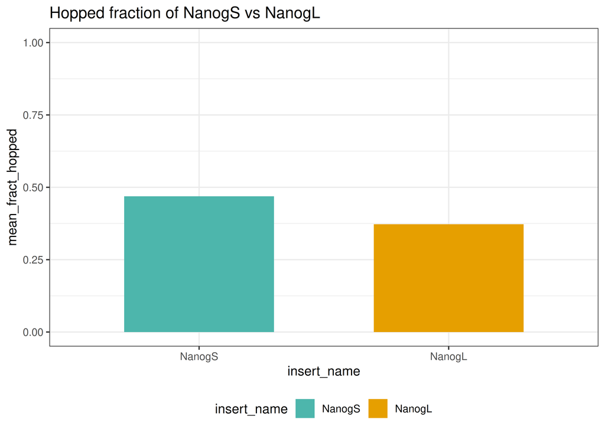

```r
#Define Nanog colors
nanog_cols <- c(
  "control" = "grey75",
  "NanogS" = "#4DB6AC",
  "NanogL" = "#E69F00"
)

# with annotated colors
pHop_eff_E1891 =
  tib_hop_eff_E1891 %>%
  mutate(insert_name = factor(insert_name, levels = c("NanogS", "NanogL"))) %>%
  ggplot(aes(x = insert_name, y = mean_fract_hopped, fill = insert_name)) +
  stat_summary(fun = mean, geom = "col", width = 0.6) +
  scale_colour_manual(values = nanog_cols) +
  scale_fill_manual(values = nanog_cols) +
  scale_y_continuous(limits = c(0, 1)) +
  ggtitle("Hopped fraction of NanogS vs NanogL") +
  theme_bw() +
  theme(legend.position = "bottom")

pHop_eff_E1891
```

**Conclusion:** Two technical replicates of NanogS (pCM002) and NanogL (pCM003) from E1845. Mean transposed fraction for NanogS = 0.47 (47%) versus NanogL = 0.37 (37%).

### Plot Density plots of files

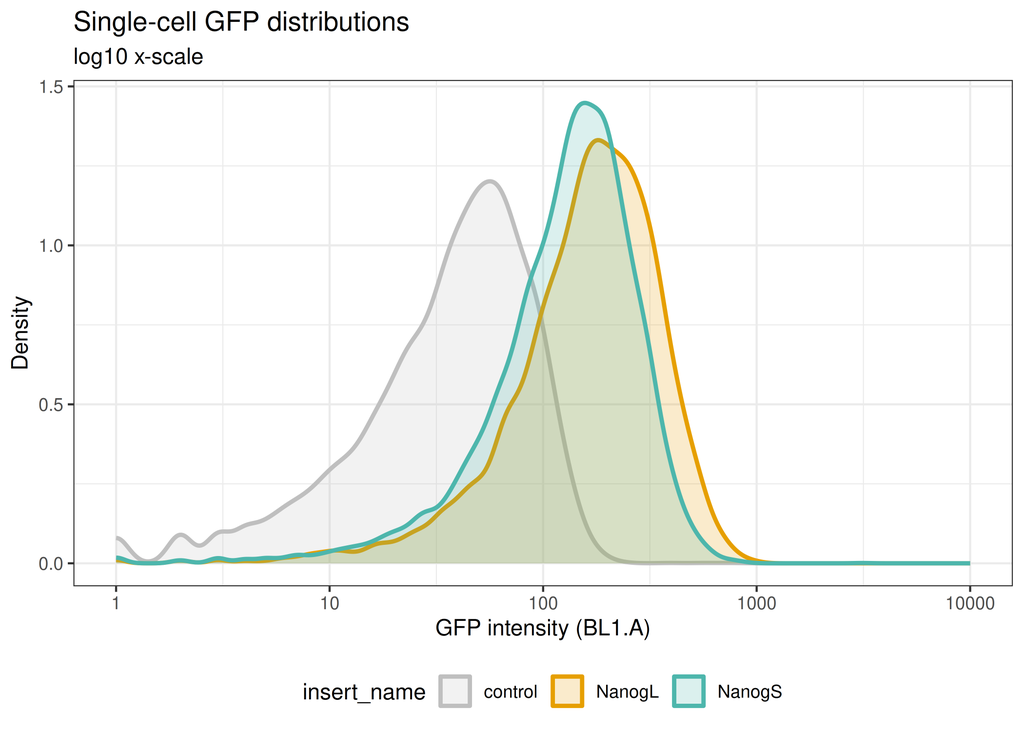

```r
# extract single-cell GFP values from each file
dens_tib_E1891 <- map_dfr(seq_along(flowset_fluo_E1891), function(i) {
  tibble(
    GFP = flowCore::exprs(flowset_fluo_E1891[[i]])[, "GFP"],
    filename = flowCore::sampleNames(flowset_fluo_E1891)[i]
  )
}) %>%
  left_join(
    fcs_tib_E1891 %>% select(filenames, insert_name, insert),
    by = c("filename" = "filenames")
  )

# density plot
pDensity_E1891 =
ggplot(dens_tib_E1891, aes(x = GFP, colour = insert_name, fill = insert_name)) +
  geom_density(alpha = 0.2, linewidth = 1) +
  scale_colour_manual(values = nanog_cols) +
  scale_fill_manual(values = nanog_cols) +
  scale_x_continuous(trans = "log10", limits = c(1, 1e4)) +
  theme_bw() +
  theme(legend.position="bottom") +
  labs(
    title = "Single-cell GFP distributions",
    subtitle = "log10 x-scale",
    x = "GFP intensity (BL1.A)",
    y = "Density")

pDensity_E1891
```

### Fig S4A - Plot combined

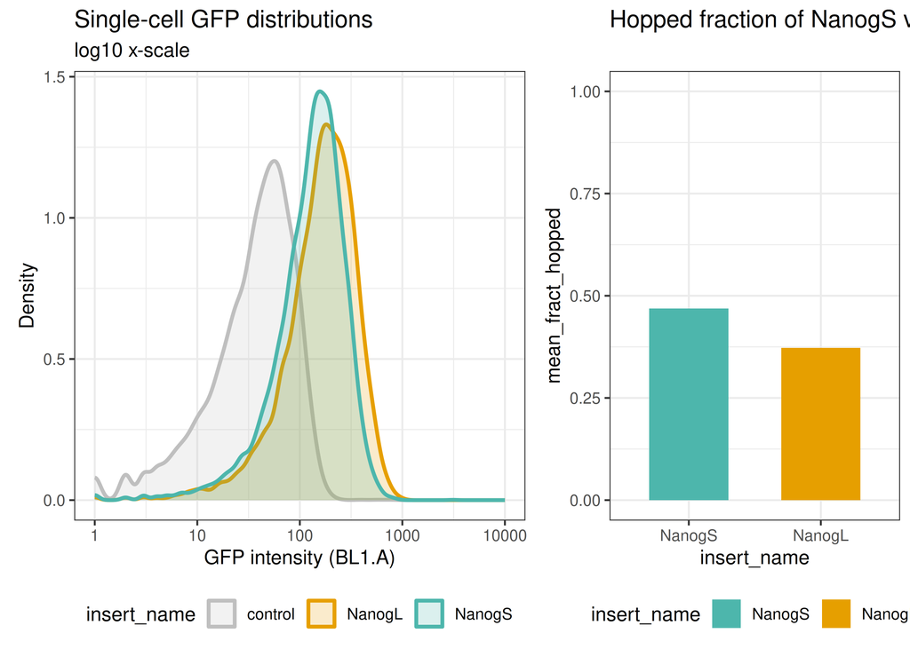

```r
plot_grid(pDensity_E1891, pHop_eff_E1891, ncol = 2, axis = "l", align = "hv", rel_widths = c(1, 0.7))
```

**Conclusion:** NanogS is 1671bp long and NanogL is 2707bp long. Both show almost the same activiyt in launch pad N1 but show a difference in hopping efficiency. This is most likely due to the size difference in the insert.